# Disaster Relief Project: Template

Jie Tang

May 09, 2022

**SYS 6018 | Spring 2022 | University of Virginia**

# 1 Introduction

Our project is aiming to predict the classification of imagery data in Haiti after the earthquake happened in 2010. Because of this huge earthquake, people who living in Haiti were displaced. Now we have ability to obtain those imagery data by a team from the Rochester Institute of Technology flew an aircraft to collect high resolution geo-referenced imagery. To find the right place from those images more effectively, we wish to design models for us to help us do this thing and that is our motivation.

# 2 Training Data / EDA

# 3 Hold-out Data / EDA

```r
# Load Required Packages
library(tidyverse)
library(ggplot2)
library(glmnet)
library(broom)
library(FNN)
library(e1071)
library(yardstick)
library(caret)
library(MASS)
library(randomForest)
library(gbm)
#Load our csv data file
data = read.csv('HaitiTraining.csv')

proj_dir = "./project_data"

#Load holdout data file
read_lines(file.path(proj_dir, "orthovnir057_ROI_NON_Blue_Tarps.txt"), n_max=15)
```

```
#>  [1] "; ENVI Output of ROIs (5.5.1) [Tue Nov 05 11:28:14 2019]"
#>  [2] "; Number of ROIs: 1"
#>  [3] "; File Dimension: 4001 x 5447"
#>  [4] ";"
#>  [5] "; ROI name: Region #1"
#>  [6] "; ROI rgb value: {255, 0, 0}"
#>  [7] "; ROI npts: 3991823"
#>  [8] ";       ID     X     Y      Map X       Map Y        Lat         Lon   B1   B2   B3"
#>  [9] "         1  1745  1128  769849.55  2049926.90  18.522675  -72.443989  104   89   63"
#> [10] "         2  1745  1129  769849.55  2049926.82  18.522674  -72.443989  101   80   60"
#> [11] "         3  1746  1129  769849.64  2049926.82  18.522674  -72.443989  103   87   69"
#> [12] "         4  1747  1129  769849.72  2049926.82  18.522674  -72.443988  107   93   72"
#> [13] "         5  1748  1129  769849.80  2049926.82  18.522674  -72.443987  109   99   68"
#> [14] "         6  1744  1129  769849.47  2049926.82  18.522674  -72.443990  103   73   53"
#> [15] "         7  1743  1130  769849.39  2049926.74  18.522674  -72.443991  100   79   56"
```

```r
#Here i have to specific dplyr::select because MASS package also have select function.
holdout_data = read_table(file.path(proj_dir, "orthovnir057_ROI_NON_Blue_Tarps.txt"), skip=8, col_names= FALSE) %>%
  dplyr::select(Red=X8, Green=X9, Blue=X10) %>%
  mutate(bluetarp=0, file="057_NON_Blue_Tarps")

holdout_data <- bind_rows(holdout_data, read_table(file.path(proj_dir, "orthovnir067_ROI_Blue_Tarps.txt"), skip=8, col_names= FALSE) %>%
  dplyr::select(Red=X8, Green=X9, Blue=X10) %>%
  mutate(bluetarp=1, file="067_Blue_Tarps"))

#Blue_Tarps_data file has different template, so we need to change a little bit.
read_lines(file.path(proj_dir, "orthovnir067_ROI_Blue_Tarps_data.txt"), n_max=15)
```

```
#>  [1] ";\tB1\tB2\tB3"  "\t77\t94\t99"   "\t79\t98\t103"  "\t77\t99\t102"  "\t76\t94\t99"
#>  [6] "\t80\t95\t103"  "\t80\t96\t107"  "\t80\t96\t106"  "\t79\t95\t105"  "\t78\t96\t104"
#> [11] "\t77\t95\t103"  "\t76\t91\t100"  "\t74\t89\t97"   "\t82\t100\t116" "\t81\t99\t114"
```

```r
holdout_data <- bind_rows(holdout_data, read_table(file.path(proj_dir, "orthovnir067_ROI_Blue_Tarps_data.txt"), skip=1, col_names= FALSE) %>%
  dplyr::select(Red=X1, Green=X2, Blue=X3) %>%
  mutate(bluetarp=1, file="067_Blue_Tarps_data"))

holdout_data <- bind_rows(holdout_data, read_table(file.path(proj_dir, "orthovnir067_ROI_NOT_Blue_Tarps.txt"), skip=8, col_names= FALSE) %>%
  dplyr::select(Red=X8, Green=X9, Blue=X10) %>%
  mutate(bluetarp=0, file="067_NOT_Blue_Tarps"))

holdout_data <- bind_rows(holdout_data, read_table(file.path(proj_dir, "orthovnir069_ROI_Blue_Tarps.txt"), skip=8, col_names= FALSE) %>%
  dplyr::select(Red=X8, Green=X9, Blue=X10) %>%
  mutate(bluetarp=1, file="069_Blue_Tarps"))

holdout_data <- bind_rows(holdout_data, read_table(file.path(proj_dir, "orthovnir069_ROI_NOT_Blue_Tarps.txt"), skip=8, col_names= FALSE) %>%
  dplyr::select(Red=X8, Green=X9, Blue=X10) %>%
  mutate(bluetarp=0, file="069_NOT_Blue_Tarps"))

holdout_data <- bind_rows(holdout_data, read_table(file.path(proj_dir, "orthovnir078_ROI_Blue_Tarps.txt"), skip=8, col_names= FALSE) %>%
  dplyr::select(Red=X8, Green=X9, Blue=X10) %>%
  mutate(bluetarp=1, file="078_Blue_Tarps"))

holdout_data <- bind_rows(holdout_data, read_table(file.path(proj_dir, "orthovnir078_ROI_NON_Blue_Tarps.txt"), skip=8, col_names= FALSE) %>%
  dplyr::select(Red=X8, Green=X9, Blue=X10) %>%
  mutate(bluetarp=0, file="078_NON_Blue_Tarps"))

#Check the columns of Haiti data
head(data)
```

```
#>        Class Red Green Blue
#> 1 Vegetation  64    67   50
#> 2 Vegetation  64    67   50
#> 3 Vegetation  64    66   49
#> 4 Vegetation  75    82   53
#> 5 Vegetation  74    82   54
#> 6 Vegetation  72    76   52
```

```r
head(holdout_data)
```

```
#> # A tibble: 6 x 5
#>     Red Green  Blue bluetarp file
#>   <dbl> <dbl> <dbl>    <dbl> <chr>
#> 1   104    89    63        0 057_NON_Blue_Tarps
#> 2   101    80    60        0 057_NON_Blue_Tarps
#> 3   103    87    69        0 057_NON_Blue_Tarps
#> 4   107    93    72        0 057_NON_Blue_Tarps
#> 5   109    99    68        0 057_NON_Blue_Tarps
#> 6   103    73    53        0 057_NON_Blue_Tarps
```

```r
#Check the summary of our data
#summary(data$Class)
#Hmisc::describe(data$Class)
Hmisc::describe(data)
```

```
#> data
#>
#>  4  Variables      63241  Observations
#> --------------------------------------------------------------------------------
#> Class
#>        n  missing distinct
#>    63241        0        5
#>
#> lowest : Blue Tarp        Rooftop          Soil             Various Non-Tarp Vegetation
#> highest: Blue Tarp        Rooftop          Soil             Various Non-Tarp Vegetation
#>
#> Value             Blue Tarp          Rooftop             Soil Various Non-Tarp
#> Frequency              2022             9903            20566             4744
#> Proportion            0.032            0.157            0.325            0.075
#>
#> Value            Vegetation
#> Frequency             26006
#> Proportion            0.411
#> --------------------------------------------------------------------------------
#> Red
#>        n  missing distinct     Info     Mean      Gmd      .05      .10
#>    63241        0      208    0.977      163    87.78       63       68
#>      .25      .50      .75      .90      .95
#>       80      163      255      255      255
#>
#> lowest :  48  49  50  51  52, highest: 251 252 253 254 255
#> --------------------------------------------------------------------------------
#> Green
#>        n  missing distinct     Info     Mean      Gmd      .05      .10
#>    63241        0      208    0.999    153.7    82.15       63       67
#>      .25      .50      .75      .90      .95
#>       78      148      226      252      255
#>
#> lowest :  48  49  50  51  52, highest: 251 252 253 254 255
#> --------------------------------------------------------------------------------
#> Blue
#>        n  missing distinct     Info     Mean      Gmd      .05      .10
#>    63241        0      212        1    125.1    69.23       50       52
#>      .25      .50      .75      .90      .95
#>       63      123      181      200      213
#>
#> lowest :  44  45  46  47  48, highest: 251 252 253 254 255
#> --------------------------------------------------------------------------------
```

```r
Hmisc::describe(holdout_data)
```

```
#> holdout_data
#>
#>  5  Variables      2008623  Observations
#> --------------------------------------------------------------------------------
#> Red
#>        n  missing distinct     Info     Mean      Gmd      .05      .10
#>  2008623        0      229        1    118.3    61.47       51       57
#>      .25      .50      .75      .90      .95
#>       76      107      139      215      255
#>
#> lowest :  27  28  29  30  31, highest: 251 252 253 254 255
#> --------------------------------------------------------------------------------
#> Green
#>        n  missing distinct     Info     Mean      Gmd      .05      .10
#>  2008623        0      228        1    105.5     54.2     49.1     56.0
#>      .25      .50      .75      .90      .95
#>     71.0     91.0    117.0    193.0    235.0
#>
#> lowest :  28  29  30  31  32, highest: 251 252 253 254 255
#> --------------------------------------------------------------------------------
#> Blue
#>        n  missing distinct     Info     Mean      Gmd      .05      .10
#>  2008623        0      231        1    82.57    45.12       40       46
#>      .25      .50      .75      .90      .95
#>       55       66       88      155      192
#>
#> lowest :  25  26  27  28  29, highest: 251 252 253 254 255
#> --------------------------------------------------------------------------------
#> bluetarp
#>        n  missing distinct     Info      Sum     Mean      Gmd
#>  2008623        0        2    0.028    18926 0.009422  0.01867
#>
#> --------------------------------------------------------------------------------
#> file
#>        n  missing distinct
#>  2008623        0        8
#>
#> lowest : 057_NON_Blue_Tarps  067_Blue_Tarps      067_Blue_Tarps_data 067_NOT_Blue_Tarps  069_Blue_Tarps
#> highest: 067_NOT_Blue_Tarps  069_Blue_Tarps      069_NOT_Blue_Tarps  078_Blue_Tarps      078_NON_Blue_Tarps
#>
#> 057_NON_Blue_Tarps (979278, 0.488), 067_Blue_Tarps (4446, 0.002),
#> 067_Blue_Tarps_data (4446, 0.002), 067_NOT_Blue_Tarps (305211, 0.152),
#> 069_Blue_Tarps (6828, 0.003), 069_NOT_Blue_Tarps (295510, 0.147),
#> 078_Blue_Tarps (3206, 0.002), 078_NON_Blue_Tarps (409698, 0.204)
#> --------------------------------------------------------------------------------
```

```r
#No missing data in both files.
```

We have 63241 data and no missing one. So we do not need to fill in or replace anything. Meanwhile, except the “Class” variable, all other predictors are numeric which means we do not need to use encoding to category variable. There are in total five classes of ‘class’ which are Blue Tarp, Rooftop, Soil, Various Non-Trap and Vegetation. Vegetation has the most proportion and Blue Tarp has the least.

And the range for color should be inside 0 to 255.

Some preprocessing: Change the multi-class prediction to binary prediction. Most of our models only fit with binary classifcation. And in our case, I consider the Blu Tarp is the most significant place to clarify. Becuase people who displaced will live with a tarp and they will need resources.

```r
is.factor(data$Class)
```

```
#> [1] FALSE
```

```r
is.factor(holdout_data$bluetarp)
```

```
#> [1] FALSE
```

```r
data$Class <- as.factor(ifelse(data$Class == "Blue Tarp", 1, 0))
holdout_data$bluetarp <- as.factor(ifelse(holdout_data$bluetarp == 1, 1, 0))
is.factor(data$Class)
```

```
#> [1] TRUE
```

```r
is.factor(holdout_data$bluetarp)
```

```
#> [1] TRUE
```

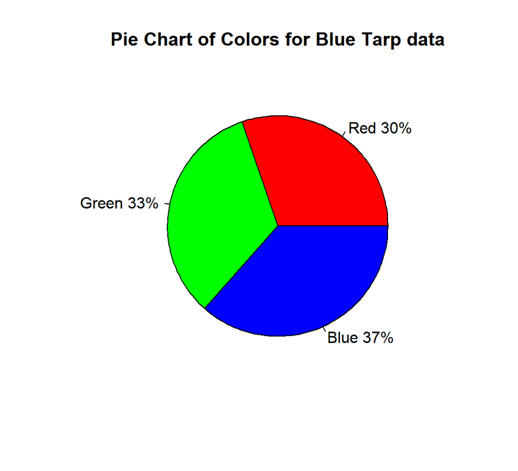

```r
#Let's take Blue Tarp class as an example, I suppose the blue numeric number will have the most part.
tarp_data = subset(data, data$Class==1)
slices <- c(sum(tarp_data$Red), sum(tarp_data$Green), sum(tarp_data$Blue))
lbls <- c("Red", "Green", "Blue")
cols <- c("Red", "Green", "Blue")
pct <- round(slices/sum(slices)*100)
lbls <- paste(lbls, pct)
lbls <- paste(lbls,"%",sep="")
pie(slices, labels = lbls, main="Pie Chart of Colors for Blue Tarp data", col=cols)
```

Blue is the most. But does not over too many. We can not simply predict it by which color is the most.

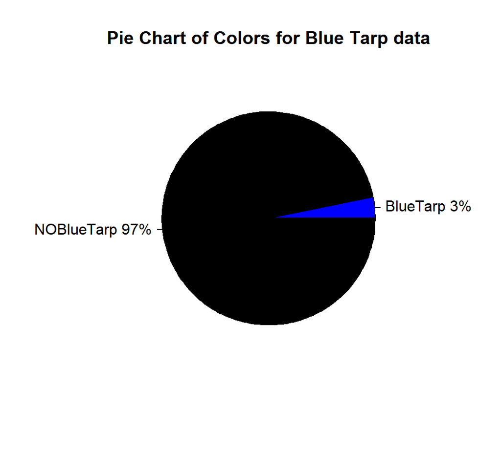

```r
l1 = length(subset(data$Class, data$Class==1))
l2 = length(subset(data$Class, data$Class==0))
l3 = length(subset(holdout_data$bluetarp, holdout_data$bluetarp==1))
l4 = length(subset(holdout_data$bluetarp, holdout_data$bluetarp==0))

slices <- c(l1, l2)
lbls <- c("BlueTarp", "NOBlueTarp")
cols <- c("Blue", "Black")
pct <- round(slices/sum(slices)*100)
lbls <- paste(lbls, pct)
lbls <- paste(lbls,"%",sep="")
pie(c(l1,l2), labels = lbls, main="Pie Chart of Colors for Blue Tarp data", col=cols)
```

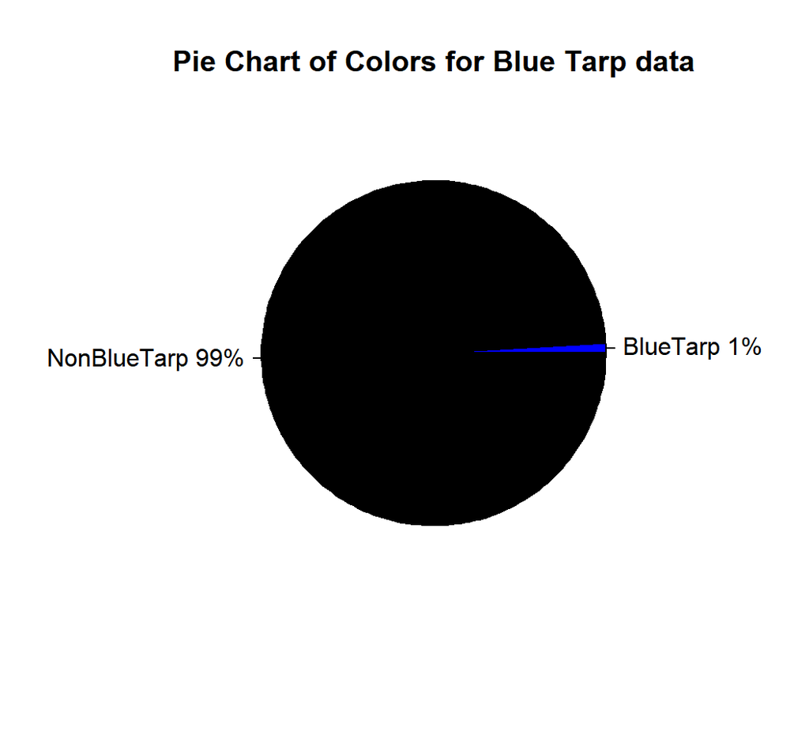

```r
slices <- c(l3, l4)
lbls <- c("BlueTarp", "NonBlueTarp")
cols <- c("Blue", "Black")
pct <- round(slices/sum(slices)*100)
lbls <- paste(lbls, pct)
lbls <- paste(lbls,"%",sep="")
pie(c(l3,l4), labels = lbls, main="Pie Chart of Colors for Blue Tarp data", col=cols)
```

By this pie chart, we can see our data is really unbalanced. Most of data we have are non-bluetarp.

# 4 Model Training

## 4.1 Set-up

```r
#- Get K-fold partition (so consistent to all models)
set.seed(1) # set seed for reproducible
n.folds = 10 # number of folds for cross-validation
fold = sample(rep(1:n.folds, length=nrow(data)))
```

## 4.2 Logistic Regression

```r
#- Iterate over folds
perf = tibble() # to save performance metric

#For logistic regression, there is no hyper parameter to tuning.

for(k in 1:10){
  #-- Set training/test data for fold k
  test = which(fold == k) # indices of holdout/validation data
  train = which(fold != k) # indices of fitting/training data
  n.val = length(test) # number of observations in validation

  lg = glm(Class ~ Red + Green + Blue, data = data, family = "binomial")
  p_hat = predict(lg, data[test,], type='response')

  #: evaluate performance
  log_loss = yardstick::mn_log_loss_vec(data$Class[test], as.numeric(p_hat), event_level = "second")
  AUROC = yardstick::roc_auc_vec(data$Class[test], as.numeric(p_hat), event_level = "second")

  out = tibble(log_loss, AUROC) %>%
  mutate(fold = k, tuning = "None")

  perf = bind_rows(perf, out)
}
```

Cross-validation performance

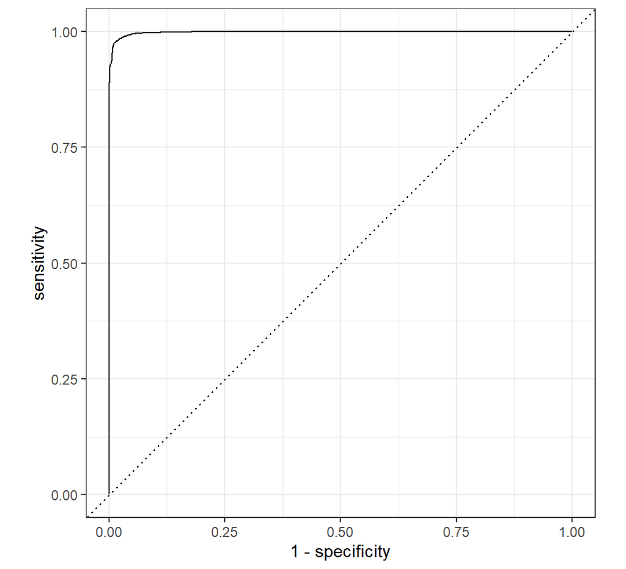

```r
pred = numeric(nrow(data))
for(v in unique(fold)) {
  # set fit/eval split
  ind_fit = which(fold != v)
  ind_eval = which(fold == v)
  fit <- glm(Class ~ ., data = data[ind_fit, ], family="binomial")
  pred[ind_eval] <- predict(fit ,data[ind_eval,], type = "response" )

}
eval_data = tibble(
  y = data$Class,
  pred = pred,
)

# ROC curves
ROC_data = yardstick::roc_curve(eval_data,
  truth = y,
  estimate = pred,
  event_level = "second")
autoplot(ROC_data)
```

```r
lg_cv_AUROC = yardstick::roc_auc_vec(data$Class, as.numeric(pred), event_level = "second")
```

ROC curve For all of the ROC curve, we use the out-of sample data. In cross-validation on training data case, we connect predictions of holdout data in 10 folds and do the out sample ROC curves. In hold-out data case, we directly use all hold-out data to do ROC curves.

————————-Threshold selection——————————–

In this disaster, we should try to find all possible survivors. In this case, we do not want to miss any picture that has chance to be Blue Tarp, we allow the mistake that a wrong recognization of BlueTarp. Our positive case is image is Blue Tarp. False Positive means we think it is Blue Tarp but it is not. False negative means we think it is not Blue Tarp but it is. So, we give more penalty to FN than FP. In this case, I take the cost of FN 5 times worse than FP in every model threshold selection.

```r
#-- Make function to calculate confusion matrix metrics
get_conf <- function(thres, y, p_hat) {
yhat = ifelse(p_hat >= thres, 1L, 0L)
tibble(threshold = thres,
TP = sum(y == 1 & yhat == 1),
FP = sum(y == 0 & yhat == 1),
FN = sum(y == 1 & yhat == 0),
TN = sum(y == 0 & yhat == 0)
)
}
```

```r
#-- Calculate for range of thresholds
thres = seq(.05, .20, length=50) # set of thresholds
perf_thres = map_df(thres, ~get_conf(., y=data$Class, p_hat = pred)) %>% mutate(cost = FN*5 + FP*1)

res <- perf_thres %>%
slice_min(cost) %>% # choose threshold with minimum costs
transmute(threshold,
Accuracy = (TP + TN)/(TP + FP + FN + TN),
TPR = TP / (TP + FN),
FPR = FP / (FP + TN),
PRE = TP / (TP + FP))
res
```

```
#> # A tibble: 1 x 5
#>   threshold Accuracy   TPR     FPR   PRE
#>       <dbl>    <dbl> <dbl>   <dbl> <dbl>
#> 1    0.0990    0.991 0.965 0.00836 0.792
```

```r
#Met two same min threshold problem
if(length(res) != 1){
  res <- res[1,]
}
lg_cv_threshold = res$threshold
lg_cv_acc = res$Accuracy
lg_cv_tpr = res$TPR
lg_cv_fpr = res$FPR
lg_cv_pre = res$PRE
```

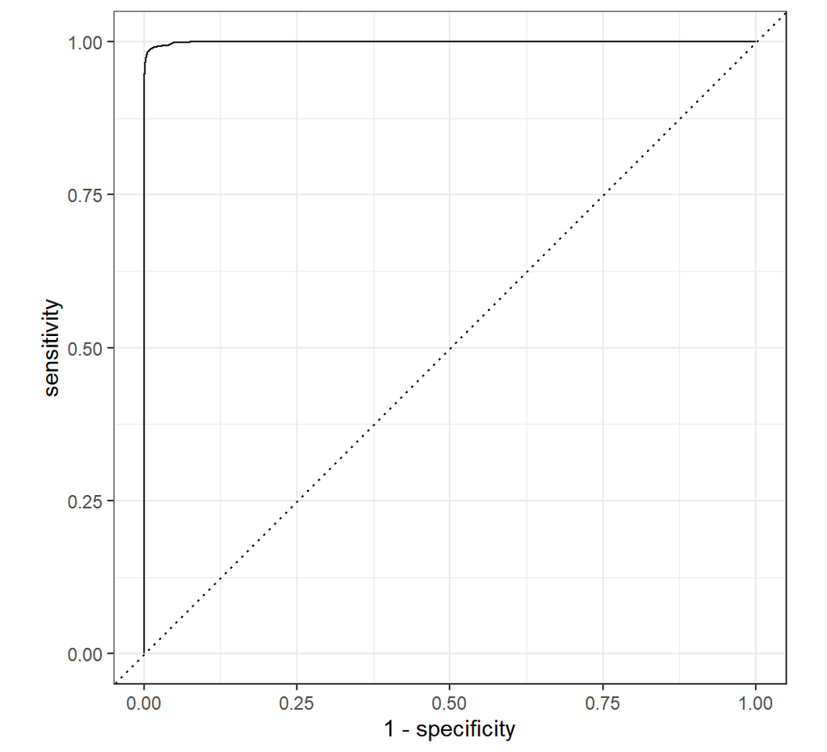

```r
#No tuning parameter for glm().
#We use holdout data to evaluate logistic model and draw AUROC curve.
#Fit model with training data and test it with holdout data.
fit = glm(Class~., data, family = "binomial")
pred = predict(fit, holdout_data, type="response")
eval_data = tibble(
  y = holdout_data$bluetarp,
  pred = pred,
  yhat = ifelse(pred > .50, 1, 0) # hard classification
)
# ROC curves builds from out-sample data
ROC_data = yardstick::roc_curve(eval_data,
  truth = y,
  estimate = pred,
  event_level = "second")
autoplot(ROC_data)
```

```r
lg_AUROC = yardstick::roc_auc_vec(holdout_data$bluetarp, as.numeric(pred), event_level = "second")
```

```r
#-- Calculate for range of thresholds
thres = seq(.05, .20, length=50) # set of thresholds
perf_thres = map_df(thres, ~get_conf(., y=holdout_data$bluetarp, p_hat = pred)) %>% mutate(cost = FN*5 + FP*1)

res <- perf_thres %>%
slice_min(cost) %>% # choose threshold with minimum costs
transmute(threshold,
Accuracy = (TP + TN)/(TP + FP + FN + TN),
TPR = TP / (TP + FN),
FPR = FP / (FP + TN),
PRE = TP / (TP + FP))
res
```

```
#> # A tibble: 1 x 5
#>   threshold Accuracy   TPR    FPR   PRE
#>       <dbl>    <dbl> <dbl>  <dbl> <dbl>
#> 1       0.2    0.952 0.998 0.0480 0.165
```

```r
#Met two same min threshold problem
if(length(res) != 1){
  res <- res[1,]
}
lg_threshold = res$threshold
lg_acc = res$Accuracy
lg_tpr = res$TPR
lg_fpr = res$FPR
lg_pre = res$PRE
```

## 4.3 KNN

For KNN, the tuning parameter will be the number of K. In KNN, we should consider about normalize each column range for a better distance calculation. But in our case, Red Green and Blue have same range, so I keep those data to fit model. Also, knn does not allow categorical data inside. So, we need to convert factor to numeric. At the same time, knn() function returns result with probability. So, we need to read attribute of model result to get probabbility.

```r
library(gmodels)
knn.data <- data
knn.data$Class <- as.numeric(ifelse(knn.data$Class == 1, 1, 0))
#Tuning parameter k that we gonna test
K = c(15, 12, 10, 8, 7, 6, 5, 4, 3)
perf = tibble()
for(i in 1:10) {
  #-- Set training/test data for fold k
  test = which(fold == i) # indices of holdout/validation data
  train = which(fold != i) # indices of fitting/training data
  cl = as.numeric(knn.data[train,1])
  n.val = length(test) # number of observations in validation

  for(k in K) {
    set.seed(1)
    knn = knn(train = knn.data[train,c(2,4)], test = knn.data[test,c(2,4)], cl = cl, k=k, prob=TRUE)
    #: estimate probability in hold out set
    #CrossTable(x = knn.data[test,1] , y = knn, prop.chisq = FALSE)
    p_hat = knn
    #p_hat = predict(knn, knn.data[test,])
    #: evaluate performance
    log_loss = yardstick::mn_log_loss_vec(data$Class[test], as.numeric(p_hat), event_level = "second")
    AUROC = yardstick::roc_auc_vec(data$Class[test], as.numeric(p_hat), event_level = "second")

    out = tibble(log_loss, AUROC) %>%
      mutate(fold = i, tuning = k, edf=n.val/k )

    perf = bind_rows(perf, out)
  }
}
```

### 4.3.1 Tuning Parameter $k$

```r
perf
```

```
#> # A tibble: 90 x 5
#>    log_loss AUROC  fold tuning   edf
#>       <dbl> <dbl> <int>  <dbl> <dbl>
#>  1     34.9 0.965     1     15  422.
#>  2     34.9 0.965     1     12  527.
#>  3     34.9 0.965     1     10  632.
#>  4     34.9 0.960     1      8  791.
#>  5     34.9 0.967     1      7  904.
#>  6     34.9 0.960     1      6 1054.
#>  7     34.9 0.965     1      5 1265
#>  8     34.9 0.948     1      4 1581.
#>  9     34.9 0.970     1      3 2108.
#> 10     34.9 0.980     2     15  422.
#> # ... with 80 more rows
```

```r
(avg_perf = perf %>%
group_by(tuning) %>%
summarize(
avg_log_loss = mean(log_loss),
avg_AUROC = mean(AUROC),
sd_log_loss = sd(log_loss),
sd_AUROC = sd(AUROC)
) %>%
arrange(avg_log_loss, -avg_AUROC))
```

```
#> # A tibble: 9 x 5
#>   tuning avg_log_loss avg_AUROC sd_log_loss sd_AUROC
#>    <dbl>        <dbl>     <dbl>       <dbl>    <dbl>
#> 1     15         34.9     0.977      0.0820  0.00823
#> 2      7         34.9     0.973      0.0820  0.00777
#> 3     12         34.9     0.971      0.0820  0.0100
#> 4      5         34.9     0.970      0.0820  0.00554
#> 5     10         34.9     0.970      0.0820  0.0110
#> 6      8         34.9     0.968      0.0820  0.00937
#> 7      3         34.9     0.966      0.0820  0.00671
#> 8      6         34.9     0.964      0.0820  0.00669
#> 9      4         34.9     0.958      0.0820  0.00695
```

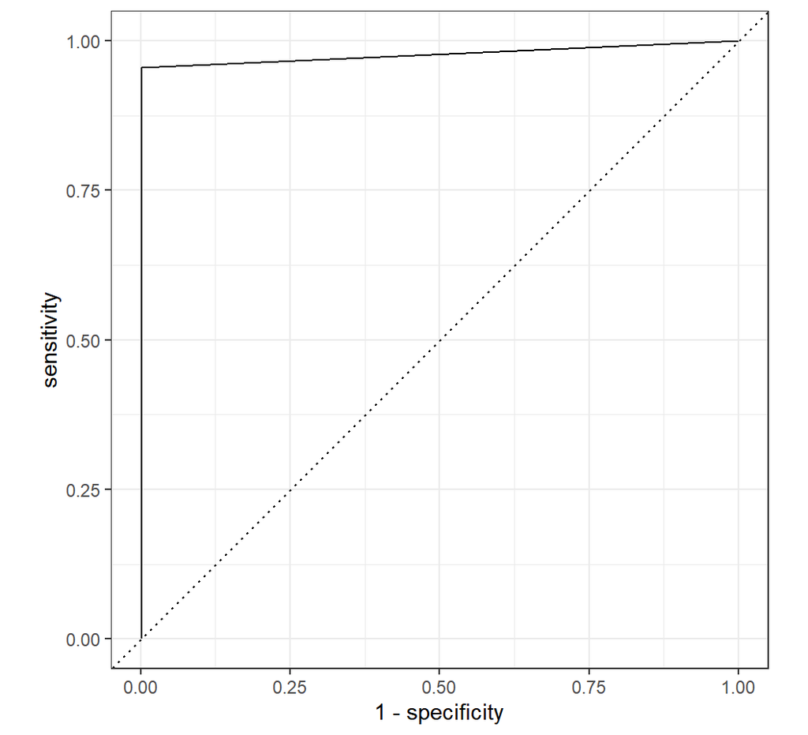

```r
#So we can see that when k=15, we have the best performance
pred = numeric(nrow(data))
for(v in unique(fold)) {
  # set fit/eval split
  ind_fit = which(fold != v)
  ind_eval = which(fold == v)
  cl = as.numeric(knn.data[ind_fit,1])
  knn = knn(train = knn.data[ind_fit,c(2,4)], test = knn.data[ind_eval,c(2,4)], cl = cl, k=15)
  #We need to change factor to numeric
  pred[ind_eval] = as.numeric(ifelse(knn == 1, 1, 0))
}


eval_data = tibble(
  y = data$Class,
  pred = pred
)
# ROC curves
ROC_data = yardstick::roc_curve(eval_data,
  truth = y,
  estimate = pred,
  event_level = "second")
autoplot(ROC_data)
```

```r
knn_cv_AUROC = yardstick::roc_auc_vec(data$Class, as.numeric(pred), event_level = "second")
```

Threshold. We use the same range of threshold [0.05,0.2]

```r
#-- Calculate for range of thresholds
perf_thres = map_df(thres, ~get_conf(., y=knn.data$Class, p_hat = pred)) %>% mutate(cost = FN*5 + FP*1)

res <- perf_thres %>%
slice_min(cost) %>% # choose threshold with minimum costs
transmute(threshold,
Accuracy = (TP + TN)/(TP + FP + FN + TN),
TPR = TP / (TP + FN),
FPR = FP / (FP + TN),
PRE = TP / (TP + FP))
res
```

```
#> # A tibble: 50 x 5
#>    threshold Accuracy   TPR     FPR   PRE
#>        <dbl>    <dbl> <dbl>   <dbl> <dbl>
#>  1    0.05      0.997 0.956 0.00216 0.936
#>  2    0.0531    0.997 0.956 0.00216 0.936
#>  3    0.0561    0.997 0.956 0.00216 0.936
#>  4    0.0592    0.997 0.956 0.00216 0.936
#>  5    0.0622    0.997 0.956 0.00216 0.936
#>  6    0.0653    0.997 0.956 0.00216 0.936
#>  7    0.0684    0.997 0.956 0.00216 0.936
#>  8    0.0714    0.997 0.956 0.00216 0.936
#>  9    0.0745    0.997 0.956 0.00216 0.936
#> 10    0.0776    0.997 0.956 0.00216 0.936
#> # ... with 40 more rows
```

```r
#Met two same min threshold problem
if(length(res) != 1){
  res <- res[1,]
}
knn_cv_threshold = res$threshold
knn_cv_acc = res$Accuracy
knn_cv_tpr = res$TPR
knn_cv_fpr = res$FPR
knn_cv_pre = res$PRE
```

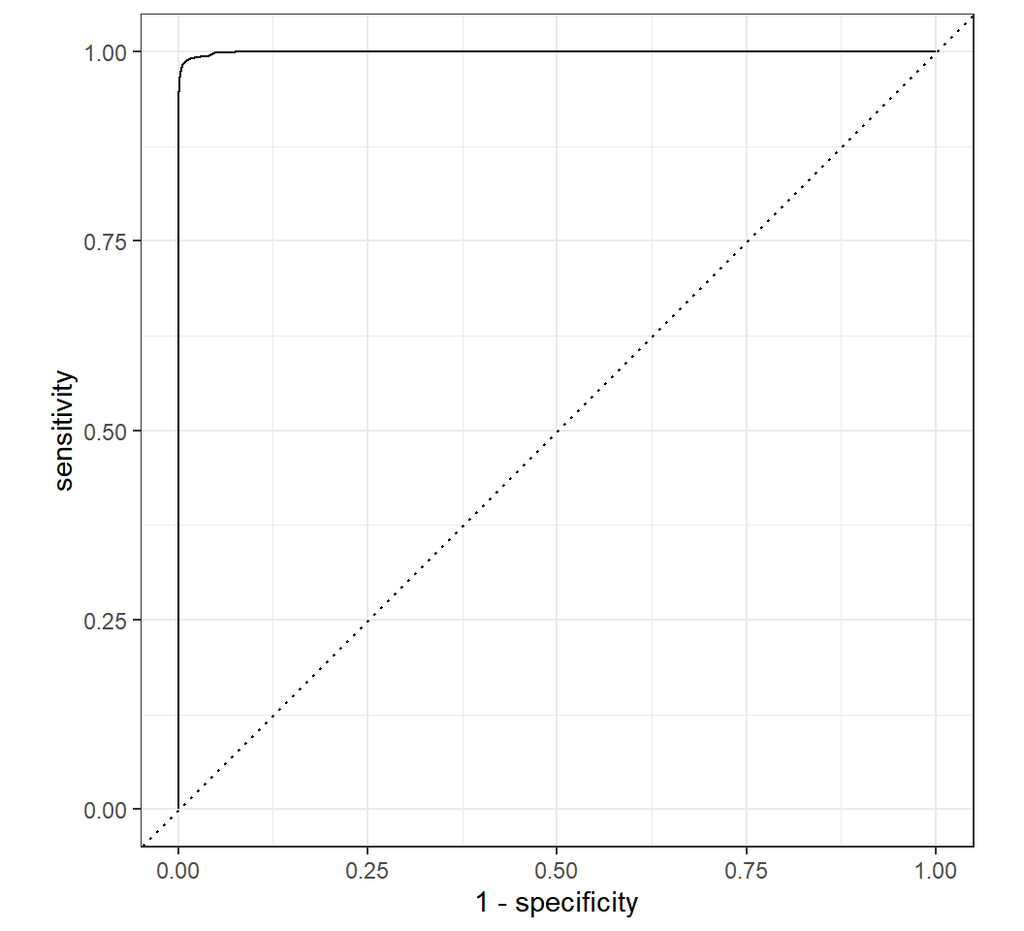

```r
#We use holdout data to evaluate knn model and draw AUROC curve.
#Fit model with training data and test it with holdout data.
pred = knn(train = knn.data[,c(2,4)], test = holdout_data[,c(1,3)], cl = knn.data$Class, k=15)
pred <- as.numeric(ifelse(pred == 1, 1, 0))


fit = glm(Class~., data, family = "binomial")
pred = predict(fit, holdout_data, type="response")
eval_data = tibble(
  y = holdout_data$bluetarp,
  pred = pred,
  yhat = ifelse(pred > .50, 1, 0) # hard classification
)
# ROC curves builds from out-sample data
ROC_data = yardstick::roc_curve(eval_data,
  truth = y,
  estimate = pred,
  event_level = "second")
autoplot(ROC_data)
```

```r
knn_AUROC = yardstick::roc_auc_vec(holdout_data$bluetarp, as.numeric(pred), event_level = "second")
```

```r
#-- Calculate for range of thresholds
perf_thres = map_df(thres, ~get_conf(., y=holdout_data$bluetarp, p_hat = pred)) %>% mutate(cost = FN*5 + FP*1)

res <- perf_thres %>%
slice_min(cost) %>% # choose threshold with minimum costs
transmute(threshold,
Accuracy = (TP + TN)/(TP + FP + FN + TN),
TPR = TP / (TP + FN),
FPR = FP / (FP + TN),
PRE = TP / (TP + FP))
res
```

```
#> # A tibble: 1 x 5
#>   threshold Accuracy   TPR    FPR   PRE
#>       <dbl>    <dbl> <dbl>  <dbl> <dbl>
#> 1       0.2    0.952 0.998 0.0480 0.165
```

```r
#Met two same min threshold problem
if(length(res) != 1){
  res <- res[1,]
}
knn_threshold = res$threshold
knn_acc = res$Accuracy
knn_tpr = res$TPR
knn_fpr = res$FPR
knn_pre = res$PRE
```

## 4.4 Penalized Logistic Regression (ElasticNet)

Model setup

```r
#- Set-up model matrix (using main, quadratic, and 2-way interactions)
fmla2 = as.formula(Class ~ poly(Red, Green, Blue, degree=2) )
X = model.matrix(fmla2, data)[, -1]
Y = data$Class
```

### 4.4.1 Tuning Parameters

In ElasticNet, we always tuning the alpha and lambda. Once we decide the alpha value, glmnet() fit models with a set of lambda values. And here I use deviance changes to tune parameters.

```r
library(glmnet)
library(broom)
#-- Initialize
alpha_seq = c(0, .25, .5, .75, 1) # set of alpha values to search

perf_alpha = tibble()
#-- Search over alpha (and lambda)
for(i in seq_along(alpha_seq)){
  a = alpha_seq[i]
  fit = cv.glmnet(X, Y, family="binomial", alpha = a,
  foldid = fold, # We use predefine cv fold as foldid argument input
  type.measure = "deviance")
  perf = broom::tidy(fit) %>% slice_min(estimate) %>% mutate(alpha = a)
  perf_alpha = bind_rows(perf_alpha, perf)
}
```

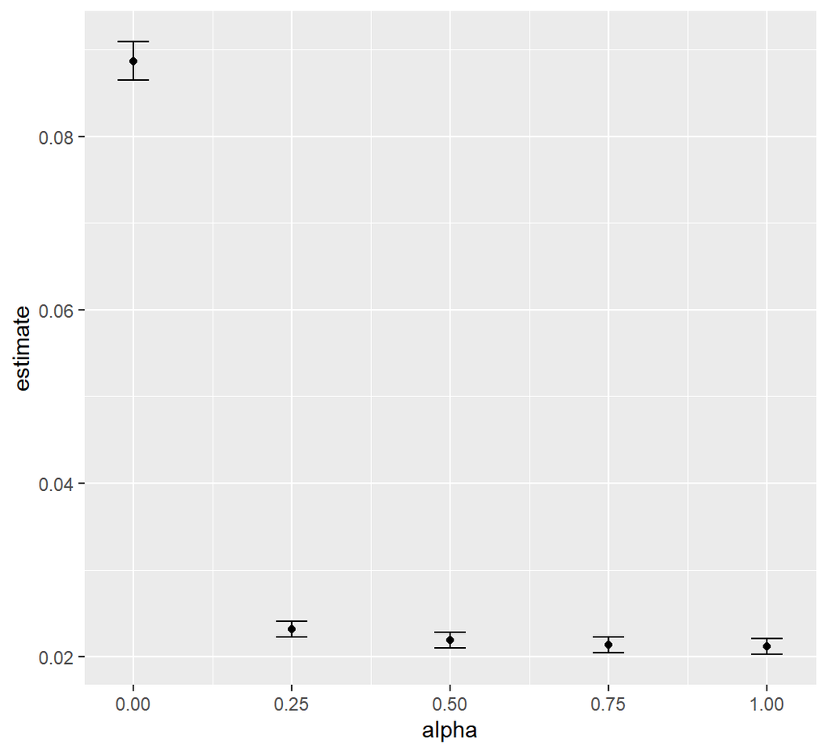

```r
perf_alpha %>%
ggplot(aes(alpha, estimate)) + geom_point() +
geom_errorbar(aes(ymin=conf.low, ymax=conf.high), width=.05)
```

We can see from this graph that when alpha is 1 (lasso), we have best performance. We store this alpha and along best lambda value for following model fitting.

```r
tune_enet = perf_alpha %>%
  slice_min(estimate) %>% # choose best performance (minimize deviance)
  dplyr::select(alpha, lambda) # keep alpha and lambda
tune_enet
```

```
#> # A tibble: 1 x 2
#>   alpha    lambda
#>   <dbl>     <dbl>
#> 1     1 0.0000223
```

Cross-validation performance

```r
pred.enet = numeric(nrow(data))
for(v in unique(fold)) {
  fit = glmnet(X[fold != v,], Y[fold != v], family="binomial",
  alpha = tune_enet$alpha)
  pred.enet[fold == v] = predict(fit, X[fold == v, ], type="response",
  s = tune_enet$lambda)
}
```

AUROC curve and Threshold selection

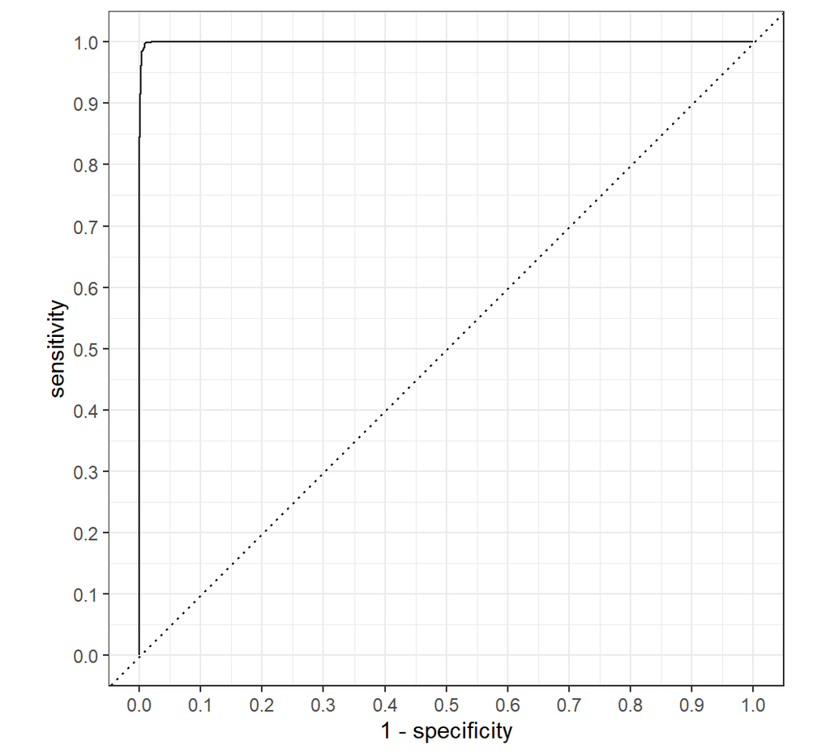

```r
pred_data = tibble(row = 1:nrow(data), fold = fold, y = Y, p_hat = pred.enet)

ROC_info = pred_data %>%
roc_curve(truth=y, estimate=p_hat, event_level="second")

ROC_info %>%
  autoplot() +
  scale_x_continuous(breaks = seq(0, 1, by=.1)) +
  scale_y_continuous(breaks = seq(0, 1, by=.1))
```

```r
eln_cv_AUROC = yardstick::roc_auc_vec(data$Class, as.numeric(pred.enet), event_level = "second")

perf_thres = map_df(thres, ~get_conf(., y=pred_data$y, p_hat = pred_data$p_hat)) %>%
  mutate(cost = FN*5 + FP*1)
perf_thres
```

```
#> # A tibble: 50 x 6
#>    threshold    TP    FP    FN    TN  cost
#>        <dbl> <int> <int> <int> <int> <dbl>
#>  1    0.05    2018   611     4 60608   631
#>  2    0.0531  2018   599     4 60620   619
#>  3    0.0561  2018   586     4 60633   606
#>  4    0.0592  2018   582     4 60637   602
#>  5    0.0622  2017   574     5 60645   599
#>  6    0.0653  2015   569     7 60650   604
#>  7    0.0684  2003   455    19 60764   550
#>  8    0.0714  1996   363    26 60856   493
#>  9    0.0745  1992   259    30 60960   409
#> 10    0.0776  1991   252    31 60967   407
#> # ... with 40 more rows
```

```r
res <- perf_thres %>%
slice_min(cost) %>% # choose threshold with minimum costs
transmute(threshold,
Accuracy = (TP + TN)/(TP + FP + FN + TN),
TPR = TP / (TP + FN),
FPR = FP / (FP + TN),
PRE = TP / (TP + FP))
res
```

```
#> # A tibble: 1 x 5
#>   threshold Accuracy   TPR     FPR   PRE
#>       <dbl>    <dbl> <dbl>   <dbl> <dbl>
#> 1    0.0898    0.996 0.984 0.00389 0.893
```

```r
#Met two same min threshold problem
if(length(res) != 1){
  res <- res[1,]
}
eln_cv_threshold = res$threshold
eln_cv_acc = res$Accuracy
eln_cv_tpr = res$TPR
eln_cv_fpr = res$FPR
eln_cv_pre = res$PRE
```

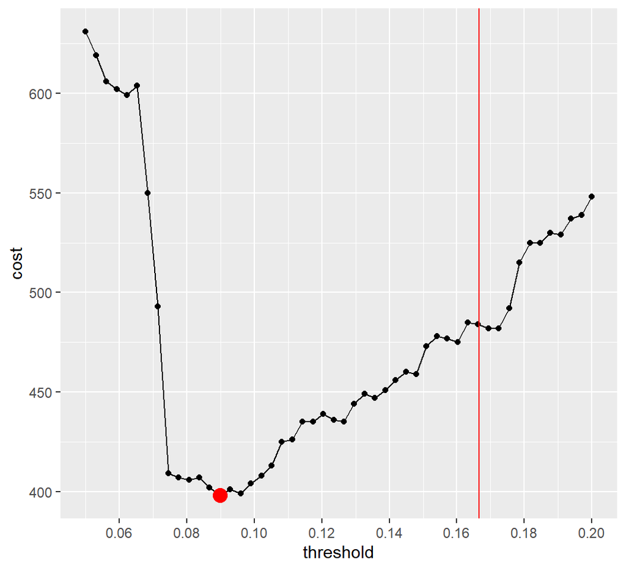

```r
perf_thres %>%
ggplot(aes(threshold, cost)) +
geom_line() +
geom_point() + geom_point(data = . %>% slice_min(cost), color="red", size=4) +
geom_vline(xintercept = 1/6, color="red") +
scale_x_continuous(breaks = seq(0, 1, by=.02))
```

Hold-out test performance

```r
fit = glmnet(X, Y, family="binomial",
  alpha = tune_enet$alpha)

fmla2 = as.formula(bluetarp ~ poly(Red, Green, Blue, degree=2) )
X = model.matrix(fmla2, holdout_data)[, -1]
pred = predict(fit, X, type="response",
  s = tune_enet$lambda)
```

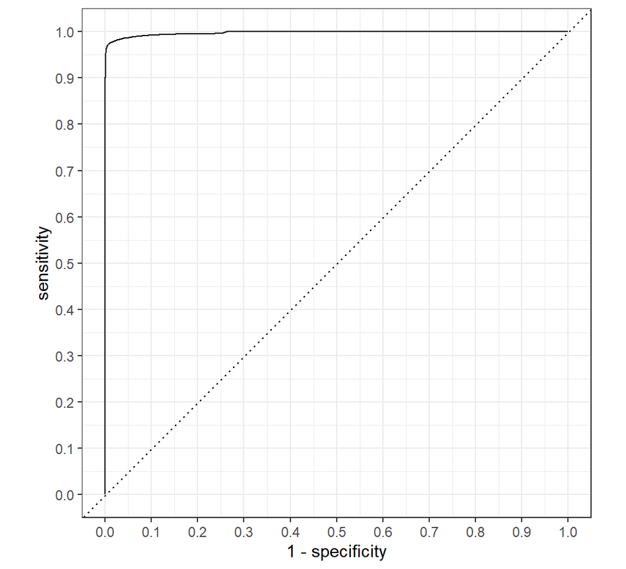

```r
pred_data = tibble(row = 1:nrow(holdout_data), y = holdout_data$bluetarp, p_hat = as.numeric(pred))

ROC_info = pred_data %>%
roc_curve(truth=y, estimate=p_hat, event_level="second")

ROC_info %>%
  autoplot() +
  scale_x_continuous(breaks = seq(0, 1, by=.1)) +
  scale_y_continuous(breaks = seq(0, 1, by=.1))
```

```r
eln_AUROC = yardstick::roc_auc_vec(holdout_data$bluetarp, as.numeric(pred), event_level = "second")
perf_thres = map_df(thres, ~get_conf(., y=pred_data$y, p_hat = pred_data$p_hat)) %>%
  mutate(cost = FN*5 + FP*1)
perf_thres
```

```
#> # A tibble: 50 x 6
#>    threshold    TP    FP    FN      TN  cost
#>        <dbl> <int> <int> <int>   <int> <dbl>
#>  1    0.05    1599     0 17327 1989697 86635
#>  2    0.0531  1510     0 17416 1989697 87080
#>  3    0.0561  1409     0 17517 1989697 87585
#>  4    0.0592  1331     0 17595 1989697 87975
#>  5    0.0622  1216     0 17710 1989697 88550
#>  6    0.0653  1132     0 17794 1989697 88970
#>  7    0.0684  1053     0 17873 1989697 89365
#>  8    0.0714   995     0 17931 1989697 89655
#>  9    0.0745   942     0 17984 1989697 89920
#> 10    0.0776   882     0 18044 1989697 90220
#> # ... with 40 more rows
```

```r
res <- perf_thres %>%
slice_min(cost) %>% # choose threshold with minimum costs
transmute(threshold,
Accuracy = (TP + TN)/(TP + FP + FN + TN),
TPR = TP / (TP + FN),
FPR = FP / (FP + TN),
PRE = TP / (TP + FP))
res
```

```
#> # A tibble: 1 x 5
#>   threshold Accuracy    TPR   FPR   PRE
#>       <dbl>    <dbl>  <dbl> <dbl> <dbl>
#> 1      0.05    0.991 0.0845     0     1
```

```r
#Met two same min threshold problem
if(length(res) != 1){
  res <- res[1,]
}
eln_threshold = res$threshold
eln_acc = res$Accuracy
eln_tpr = res$TPR
eln_fpr = res$FPR
eln_pre = res$PRE
```

## 4.5 Support Vector Machines (SVM)

For SVM tuning, because of time I am just gonna use three folds to tune our parameter. We use gridsearch to tuning hyper-paramters gamma and cost.

```r
#- Set tuning parameter grid search
grid = expand_grid(
  kernel = "radial",
  gamma = seq(1/8, 2, length=4),
  cost = 10^seq(-2,5, length=4)
)

perf = tibble()
for(i in 1:3){ # We only use three folds here
  #-- Set training/test data for fold i
  test = which(fold == i) # indices of holdout/validation data
  train = which(fold != i) # indices of fitting/training data
  n.val = length(test) # number of observations in validation
  #-- loop over tuning grid
  for(j in 1:nrow(grid)){
    tpars = grid[j,]
    #: fit model (i.e., estimate model parameters)
    fit = e1071::svm(Class ~ Red + Green + Blue, data = data[train,], type = "C-classification", probability=TRUE, # enable probability output
                     scale = TRUE, kernel = tpars$kernel, gamma = tpars$gamma,
                     cost = tpars$cost)
    #: estimate probability in hold out set
    p_hat = predict(fit, data[test,], probability = TRUE) %>%
    attr("probabilities") %>% .[,"1"]
    #: evaluate performance
    log_loss = yardstick::mn_log_loss_vec(data$Class[test], p_hat, event_level = "second")
    AUROC = yardstick::roc_auc_vec(data$Class[test], p_hat, event_level = "second")
    eval = tibble(log_loss, AUROC) %>%
    mutate(fold = i, tuning = j, n.val, kernel=tpars$kernel, gamma=tpars$gamma,
    cost=tpars$cost)

    perf = bind_rows(perf, eval)
  }
}
```

### 4.5.1 Tuning Parameters

```r
perf
```

```
#> # A tibble: 48 x 8
#>    log_loss AUROC  fold tuning n.val kernel gamma      cost
#>       <dbl> <dbl> <int>  <int> <int> <chr>  <dbl>     <dbl>
#>  1  0.0225  0.997     1      1  6325 radial 0.125      0.01
#>  2  0.0119  1.00      1      2  6325 radial 0.125      2.15
#>  3  0.00907 1.00      1      3  6325 radial 0.125    464.
#>  4  0.00857 1.00      1      4  6325 radial 0.125 100000
#>  5  0.0201  0.999     1      5  6325 radial 0.75       0.01
#>  6  0.0104  1.00      1      6  6325 radial 0.75       2.15
#>  7  0.00893 1.00      1      7  6325 radial 0.75     464.
#>  8  0.0103  1.00      1      8  6325 radial 0.75  100000
#>  9  0.0203  0.999     1      9  6325 radial 1.38       0.01
#> 10  0.00988 1.00      1     10  6325 radial 1.38       2.15
#> # ... with 38 more rows
```

```r
(avg_perf = perf %>%
  group_by(tuning, kernel, gamma, cost) %>%
  summarize(
    avg_log_loss = mean(log_loss),
    avg_AUROC = mean(AUROC),
    sd_log_loss = sd(log_loss),
    sd_AUROC = sd(AUROC)
  ) %>%
  arrange(avg_log_loss, -avg_AUROC))
```

```
#> # A tibble: 16 x 8
#> # Groups:   tuning, kernel, gamma [16]
#>    tuning kernel gamma      cost avg_log_loss avg_AUROC sd_log_loss  sd_AUROC
#>     <int> <chr>  <dbl>     <dbl>        <dbl>     <dbl>       <dbl>     <dbl>
#>  1     15 radial 2        464.        0.00729     1.00     0.00131  0.000115
#>  2      4 radial 0.125 100000         0.00739     1.00     0.00107  0.000115
#>  3     11 radial 1.38     464.        0.00764     1.00     0.00130  0.000111
#>  4      7 radial 0.75     464.        0.00772     1.00     0.00111  0.0000624
#>  5      3 radial 0.125    464.        0.00802     1.00     0.000983 0.0000910
#>  6      8 radial 0.75  100000         0.00843     1.00     0.00160  0.000127
#>  7     10 radial 1.38       2.15      0.00853     1.00     0.00140  0.0000941
#>  8     14 radial 2          2.15      0.00860     1.00     0.00162  0.0000901
#>  9     12 radial 1.38  100000         0.00866     1.00     0.00150  0.000202
#> 10      6 radial 0.75       2.15      0.00881     1.00     0.00150  0.0000851
#> 11     16 radial 2     100000         0.00885     1.00     0.00197  0.000141
#> 12      2 radial 0.125      2.15      0.0101      1.00     0.00183  0.000104
#> 13      5 radial 0.75       0.01      0.0186      0.999    0.00283  0.000178
#> 14     13 radial 2          0.01      0.0187      0.999    0.00248  0.000178
#> 15      9 radial 1.38       0.01      0.0190      0.999    0.00270  0.000186
#> 16      1 radial 0.125      0.01      0.0212      0.998    0.00232  0.000570
```

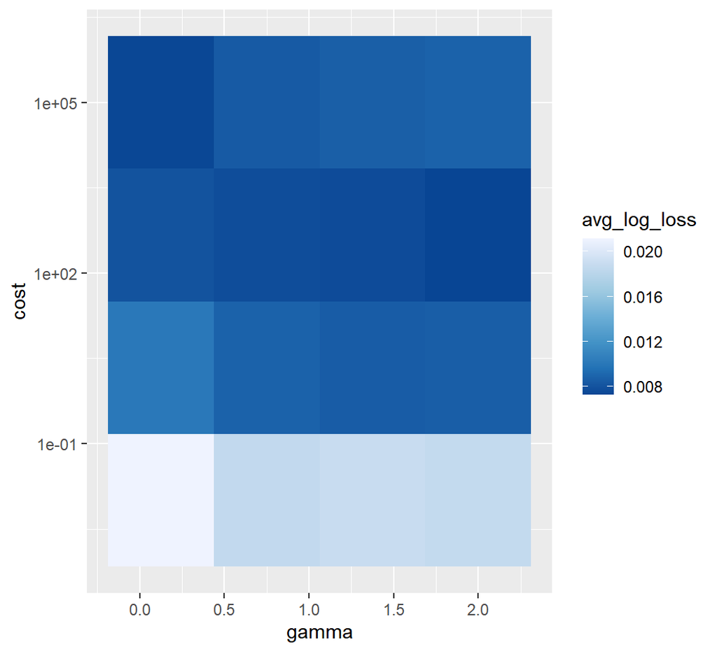

```r
ggplot(avg_perf, aes(gamma, cost, fill=avg_log_loss)) +
geom_tile() + scale_y_log10() +
scale_fill_distiller()
```

```r
tune_svm = list(cost = 400, gamma = 2, kernel = "radial")
```

From performance table, the best tuning parameters are gamma = 2.0 and cost = 464. From this graph, we can see the area with least average log loss is when also around gamma = 2.0 cost = 400. Based on those result and easy calculation, I will choose gamma = 2.0 and cost = 400 for my best svm model.

Cross-validation performance

```r
pred = numeric(nrow(data))
for(v in unique(fold)) {
  # set fit/eval split
  ind_fit = which(fold != v)
  ind_eval = which(fold == v)
  # fit SVM (for specific tuning parameters)
  fit = e1071::svm(Class ~ Red + Green + Blue,
  data = data[ind_fit,],
  type = "C-classification",
  probability=TRUE, # enable probability output
  #: tuning parameters
  scale = TRUE,
  kernel = tune_svm$kernel,
  gamma = tune_svm$gamma,
  cost = tune_svm$cost)
  # estimate probability in hold out set
  pred[ind_eval] = predict(fit, data[ind_eval,], probability = TRUE) %>%
  attr("probabilities") %>% .[,"1"]
}
```

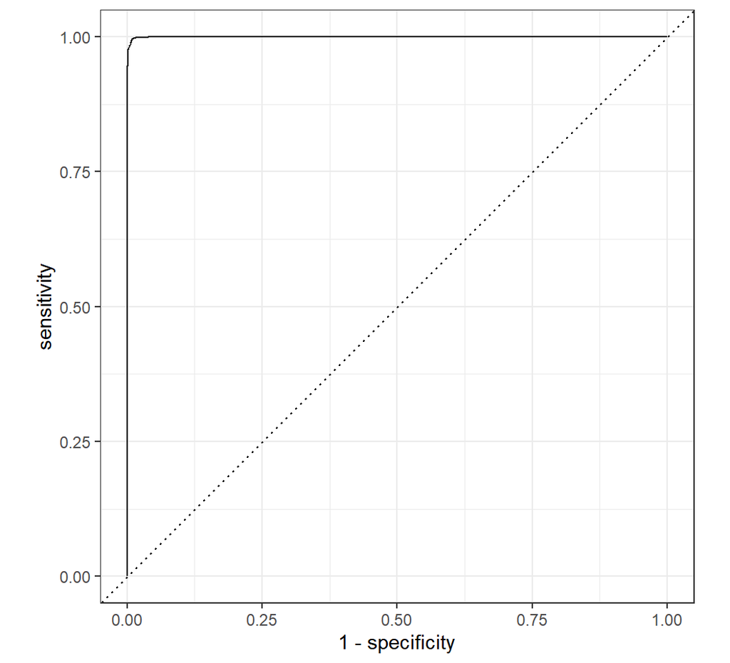

```r
eval_data = tibble( y = data$Class, pred = pred,
                    yhat = ifelse(pred > .50, 1, 0))
# ROC curves
ROC_data = yardstick::roc_curve(eval_data, truth = y, estimate = pred,
                                event_level = "second")
autoplot(ROC_data)
```

```r
svm_cv_AUROC = yardstick::roc_auc_vec(data$Class, as.numeric(pred), event_level = "second")
perf_thres = map_df(thres, ~get_conf(., y=data$Class, p_hat = pred)) %>%
  mutate(cost = FN*5 + FP*1)

res <- perf_thres %>%
  slice_min(cost) %>% # choose threshold with minimum costs
  transmute(threshold,Accuracy = (TP + TN)/(TP + FP + FN + TN),
TPR = TP / (TP + FN),
FPR = FP / (FP + TN),
PRE = TP / (TP + FP))
res
```

```
#> # A tibble: 1 x 5
#>   threshold Accuracy   TPR     FPR   PRE
#>       <dbl>    <dbl> <dbl>   <dbl> <dbl>
#> 1     0.145    0.997 0.979 0.00242 0.930
```

```r
#Met two same min threshold problem
if(length(res) != 1){
  res <- res[1,]
}
svm_cv_threshold = res$threshold
svm_cv_acc = res$Accuracy
svm_cv_tpr = res$TPR
svm_cv_fpr = res$FPR
svm_cv_pre = res$PRE
```

Hold-out data performance

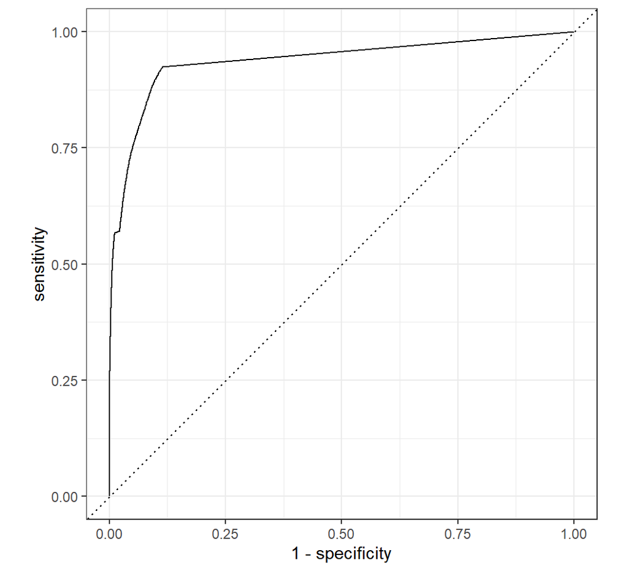

```r
pred = numeric(nrow(holdout_data))

fit = e1071::svm(Class ~ Red + Green + Blue, data = data[], type = "C-classification", probability=TRUE, # enable probability output
  #: tuning parameters
  scale = TRUE, kernel = tune_svm$kernel, gamma = tune_svm$gamma, cost = tune_svm$cost)
  # estimate probability in hold out set
  pred = predict(fit, holdout_data, probability = TRUE) %>% attr("probabilities") %>% .[,"1"]

eval_data = tibble( y = holdout_data$bluetarp, pred = pred,
                    yhat = ifelse(pred > .50, 1, 0))
# ROC curves
ROC_data = yardstick::roc_curve(eval_data, truth = y, estimate = pred,
                                event_level = "second")
autoplot(ROC_data)
```

```r
svm_AUROC = yardstick::roc_auc_vec(holdout_data$bluetarp, as.numeric(pred), event_level = "second")
perf_thres = map_df(thres, ~get_conf(., y=holdout_data$bluetarp, p_hat = pred)) %>%
  mutate(cost = FN*5 + FP*1)

res <- perf_thres %>%
  slice_min(cost) %>% # choose threshold with minimum costs
  transmute(threshold,Accuracy = (TP + TN)/(TP + FP + FN + TN),
TPR = TP / (TP + FN),
FPR = FP / (FP + TN),
PRE = TP / (TP + FP))
res
```

```
#> # A tibble: 1 x 5
#>   threshold Accuracy   TPR     FPR   PRE
#>       <dbl>    <dbl> <dbl>   <dbl> <dbl>
#> 1       0.2    0.986 0.543 0.00950 0.352
```

```r
#Met two same min threshold problem
if(length(res) != 1){
  res <- res[1,]
}
svm_threshold = res$threshold
svm_acc = res$Accuracy
svm_tpr = res$TPR
svm_fpr = res$FPR
svm_pre = res$PRE
```

## 4.6 Naive Bayes

There is no hyper-parameter to tune in Naive Bayes. We directly use model to evaluate training data and hold-out data.

Cross-validation performance

```r
library(naivebayes)
pred = numeric(nrow(data))
for(v in unique(fold)) {
  # set fit/eval split
  ind_fit = which(fold != v)
  ind_eval = which(fold == v)
  #naive-bayes model fitting
  set.seed(1)
  fit = naiveBayes(Class~., data = data[ind_fit,])
  # estimate probability in hold out set
  pred[ind_eval] = predict(fit, data[ind_eval,], type="raw")[,2]
}
```

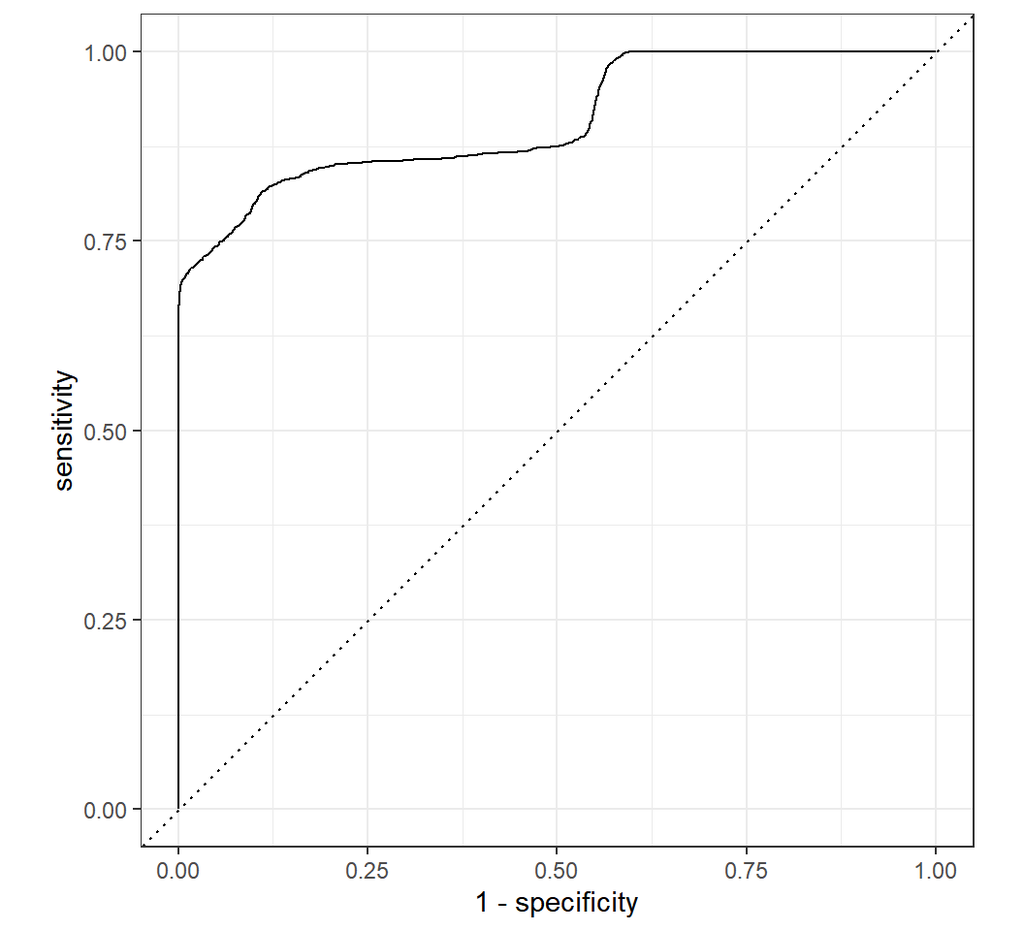

```r
eval_data = tibble( y = data$Class, pred = pred,
                    yhat = ifelse(pred > .50, 1, 0))
# ROC curves
ROC_data = yardstick::roc_curve(eval_data, truth = y, estimate = pred,
                                event_level = "second")
autoplot(ROC_data)
```

```r
nb_cv_AUROC = yardstick::roc_auc_vec(data$Class, as.numeric(pred), event_level = "second")
perf_thres = map_df(thres, ~get_conf(., y=data$Class, p_hat = pred)) %>%
  mutate(cost = FN*5 + FP*1)

res <- perf_thres %>%
  slice_min(cost) %>% # choose threshold with minimum costs
  transmute(threshold,Accuracy = (TP + TN)/(TP + FP + FN + TN),
TPR = TP / (TP + FN),
FPR = FP / (FP + TN),
PRE = TP / (TP + FP))
res
```

```
#> # A tibble: 1 x 5
#>   threshold Accuracy   TPR     FPR   PRE
#>       <dbl>    <dbl> <dbl>   <dbl> <dbl>
#> 1     0.166    0.988 0.685 0.00245 0.902
```

```r
#Met two same min threshold problem
if(length(res) != 1){
  res <- res[1,]
}
nb_cv_threshold = res$threshold
nb_cv_acc = res$Accuracy
nb_cv_tpr = res$TPR
nb_cv_fpr = res$FPR
nb_cv_pre = res$PRE
```

Hold-out data performance

```r
#We use training data to fit model and evaluate it by hold-out data.
fit = naiveBayes(Class~., data = data)
# estimate probability in hold out set
pred = predict(fit, holdout_data, type="raw")[,2]
```

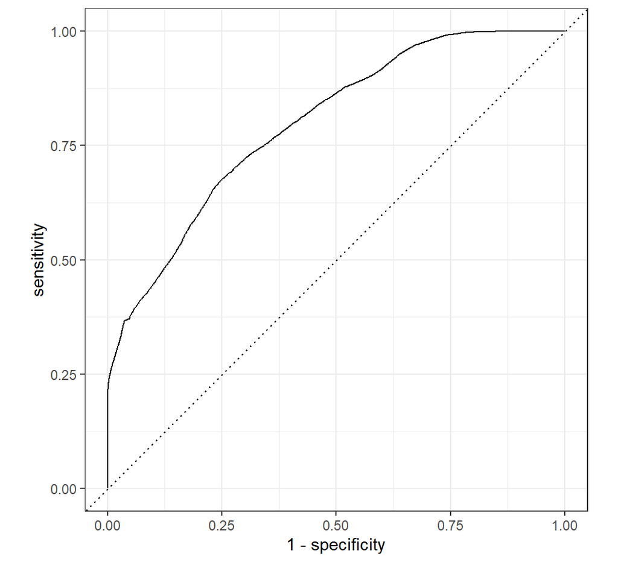

```r
eval_data = tibble( y = holdout_data$bluetarp, pred = pred,
                    yhat = ifelse(pred > .50, 1, 0))
# ROC curves
ROC_data = yardstick::roc_curve(eval_data, truth = y, estimate = pred,
                                event_level = "second")
autoplot(ROC_data)
```

```r
nb_AUROC = yardstick::roc_auc_vec(holdout_data$bluetarp, as.numeric(pred), event_level = "second")
perf_thres = map_df(thres, ~get_conf(., y=holdout_data$bluetarp, p_hat = pred)) %>%
  mutate(cost = FN*5 + FP*1)

res <- perf_thres %>%
  slice_min(cost) %>% # choose threshold with minimum costs
  transmute(threshold,Accuracy = (TP + TN)/(TP + FP + FN + TN),
TPR = TP / (TP + FN),
FPR = FP / (FP + TN),
PRE = TP / (TP + FP))
res
```

```
#> # A tibble: 1 x 5
#>   threshold Accuracy   TPR     FPR   PRE
#>       <dbl>    <dbl> <dbl>   <dbl> <dbl>
#> 1       0.2    0.990 0.232 0.00244 0.475
```

```r
#Met two same min threshold problem
if(length(res) != 1){
  res <- res[1,]
}
nb_threshold = res$threshold
nb_acc = res$Accuracy
nb_tpr = res$TPR
nb_fpr = res$FPR
nb_pre = res$PRE
```

## 4.7 LDA

There is no tuneable hyper-parameter in LDA. So, we just get the performance of training data by cross-validation and holdout data by model fitted with all training data.

```r
pred = numeric(nrow(data))
for(v in unique(fold)) {
  # set fit/eval split
  ind_fit = which(fold != v)
  ind_eval = which(fold == v)
  #lda model fitting
  fit = lda(Class~., data = data[ind_fit,])
  pred[ind_eval] = as.numeric(as.character(predict(fit, data[ind_eval,])$class))
}
```

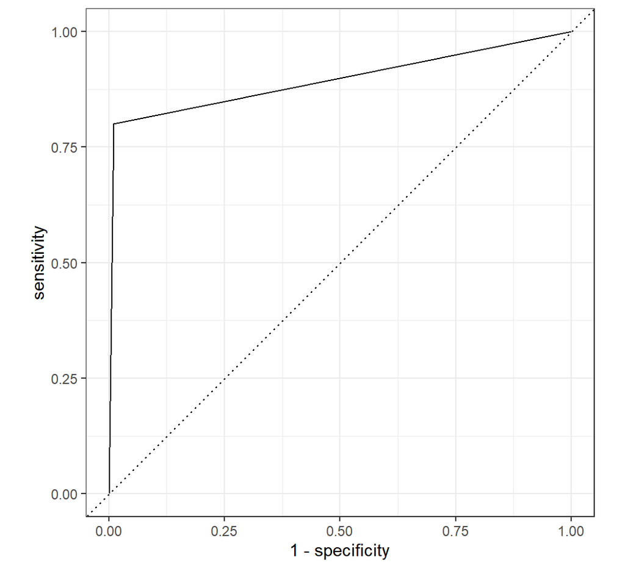

```r
eval_data = tibble( y = data$Class, pred = pred)
# ROC curves
ROC_data = yardstick::roc_curve(eval_data, truth = y, estimate = pred,
                                event_level = "second")
autoplot(ROC_data)
```

```r
lda_cv_AUROC = yardstick::roc_auc_vec(data$Class, as.numeric(pred), event_level = "second")
perf_thres = map_df(thres, ~get_conf(., y=data$Class, p_hat = pred)) %>%
  mutate(cost = FN*5 + FP*1)

res <- perf_thres %>%
  slice_min(cost) %>% # choose threshold with minimum costs
  transmute(threshold,Accuracy = (TP + TN)/(TP + FP + FN + TN),
TPR = TP / (TP + FN),
FPR = FP / (FP + TN),
PRE = TP / (TP + FP))
res
```

```
#> # A tibble: 50 x 5
#>    threshold Accuracy   TPR    FPR   PRE
#>        <dbl>    <dbl> <dbl>  <dbl> <dbl>
#>  1    0.05      0.984 0.801 0.0101 0.724
#>  2    0.0531    0.984 0.801 0.0101 0.724
#>  3    0.0561    0.984 0.801 0.0101 0.724
#>  4    0.0592    0.984 0.801 0.0101 0.724
#>  5    0.0622    0.984 0.801 0.0101 0.724
#>  6    0.0653    0.984 0.801 0.0101 0.724
#>  7    0.0684    0.984 0.801 0.0101 0.724
#>  8    0.0714    0.984 0.801 0.0101 0.724
#>  9    0.0745    0.984 0.801 0.0101 0.724
#> 10    0.0776    0.984 0.801 0.0101 0.724
#> # ... with 40 more rows
```

```r
#Met two same min threshold problem
if(length(res) != 1){
  res <- res[1,]
}
lda_cv_threshold = res$threshold
lda_cv_acc = res$Accuracy
lda_cv_tpr = res$TPR
lda_cv_fpr = res$FPR
lda_cv_pre = res$PRE
```

Holdout data performance

```r
pred = numeric(nrow(holdout_data))

fit = lda(Class~., data = data)
pred = as.numeric(as.character(predict(fit, holdout_data)$class))
```

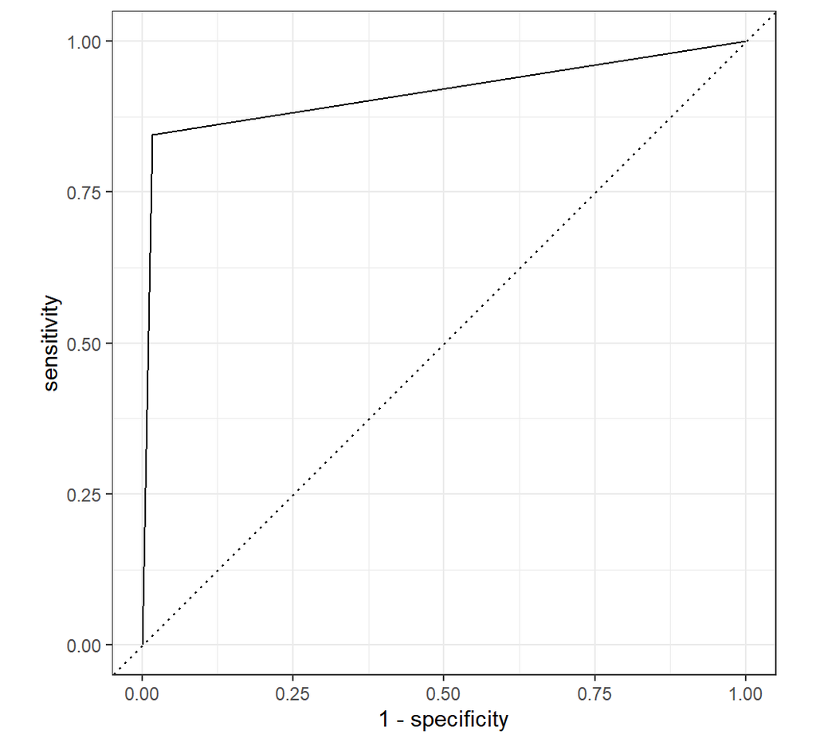

```r
eval_data = tibble( y = holdout_data$bluetarp, pred = pred)
# ROC curves
ROC_data = yardstick::roc_curve(eval_data, truth = y, estimate = pred,
                                event_level = "second")
autoplot(ROC_data)
```

```r
lda_AUROC = yardstick::roc_auc_vec(holdout_data$bluetarp, as.numeric(pred), event_level = "second")
perf_thres = map_df(thres, ~get_conf(., y=holdout_data$bluetarp, p_hat = pred)) %>%
  mutate(cost = FN*5 + FP*1)

res <- perf_thres %>%
  slice_min(cost) %>% # choose threshold with minimum costs
  transmute(threshold,Accuracy = (TP + TN)/(TP + FP + FN + TN),
TPR = TP / (TP + FN),
FPR = FP / (FP + TN),
PRE = TP / (TP + FP))
res
```

```
#> # A tibble: 50 x 5
#>    threshold Accuracy   TPR    FPR   PRE
#>        <dbl>    <dbl> <dbl>  <dbl> <dbl>
#>  1    0.05      0.981 0.846 0.0172 0.319
#>  2    0.0531    0.981 0.846 0.0172 0.319
#>  3    0.0561    0.981 0.846 0.0172 0.319
#>  4    0.0592    0.981 0.846 0.0172 0.319
#>  5    0.0622    0.981 0.846 0.0172 0.319
#>  6    0.0653    0.981 0.846 0.0172 0.319
#>  7    0.0684    0.981 0.846 0.0172 0.319
#>  8    0.0714    0.981 0.846 0.0172 0.319
#>  9    0.0745    0.981 0.846 0.0172 0.319
#> 10    0.0776    0.981 0.846 0.0172 0.319
#> # ... with 40 more rows
```

```r
#Met two same min threshold problem
if(length(res) != 1){
  res <- res[1,]
}
lda_threshold = res$threshold
lda_acc = res$Accuracy
lda_tpr = res$TPR
lda_fpr = res$FPR
lda_pre = res$PRE
```

## 4.8 QDA

There is no tuneable hyper-parameter in QDA as well. So, we just get the performance of training data by cross-validation and holdout data by model fitted with all training data.

Cross-validation performance

```r
pred = numeric(nrow(data))
for(v in unique(fold)) {
  # set fit/eval split
  ind_fit = which(fold != v)
  ind_eval = which(fold == v)
  #qda model fitting
  fit = qda(Class~., data = data[ind_fit,])
  pred[ind_eval] = as.numeric(as.character(predict(fit, data[ind_eval,])$class))
}
```

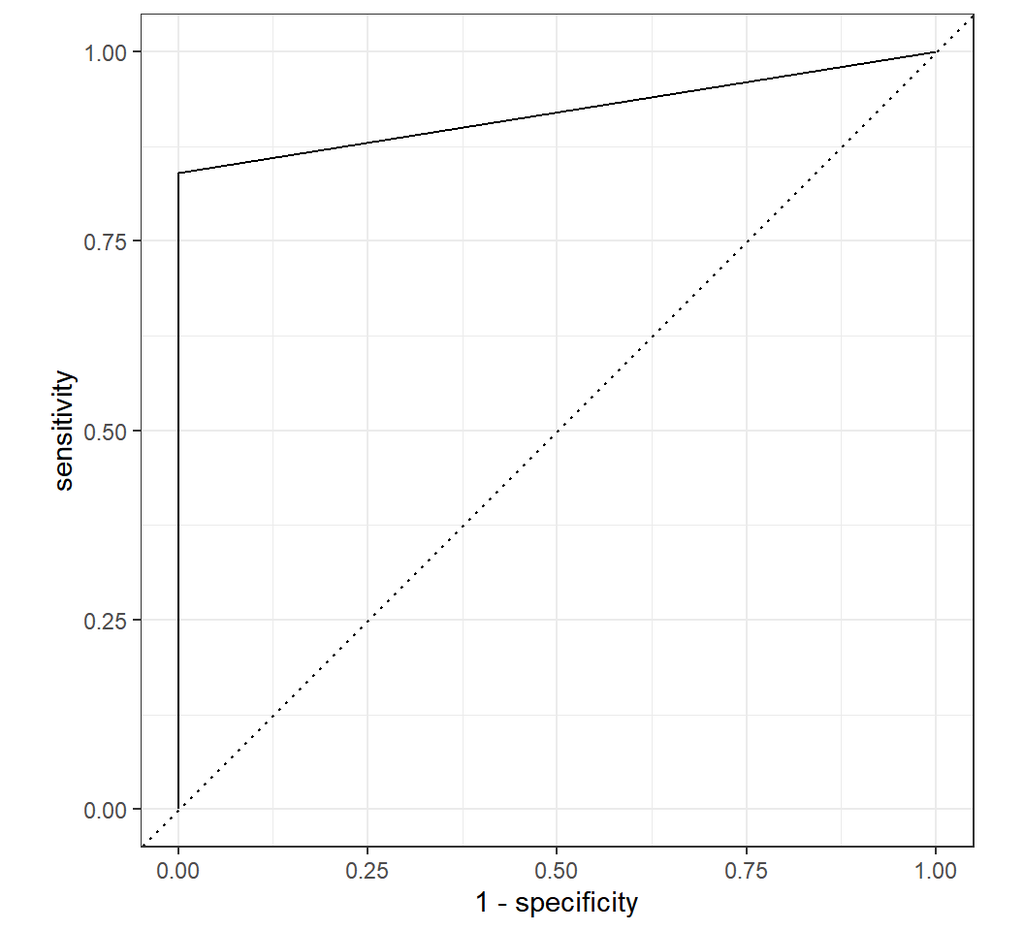

```r
eval_data = tibble( y = data$Class, pred = pred)
# ROC curves
ROC_data = yardstick::roc_curve(eval_data, truth = y, estimate = pred,
                                event_level = "second")
autoplot(ROC_data)
```

```r
qda_cv_AUROC = yardstick::roc_auc_vec(data$Class, as.numeric(pred), event_level = "second")
perf_thres = map_df(thres, ~get_conf(., y=data$Class, p_hat = pred)) %>%
  mutate(cost = FN*5 + FP*1)

res <- perf_thres %>%
  slice_min(cost) %>% # choose threshold with minimum costs
  transmute(threshold,Accuracy = (TP + TN)/(TP + FP + FN + TN),
TPR = TP / (TP + FN),
FPR = FP / (FP + TN),
PRE = TP / (TP + FP))
res
```

```
#> # A tibble: 50 x 5
#>    threshold Accuracy   TPR      FPR   PRE
#>        <dbl>    <dbl> <dbl>    <dbl> <dbl>
#>  1    0.05      0.995 0.840 0.000294 0.990
#>  2    0.0531    0.995 0.840 0.000294 0.990
#>  3    0.0561    0.995 0.840 0.000294 0.990
#>  4    0.0592    0.995 0.840 0.000294 0.990
#>  5    0.0622    0.995 0.840 0.000294 0.990
#>  6    0.0653    0.995 0.840 0.000294 0.990
#>  7    0.0684    0.995 0.840 0.000294 0.990
#>  8    0.0714    0.995 0.840 0.000294 0.990
#>  9    0.0745    0.995 0.840 0.000294 0.990
#> 10    0.0776    0.995 0.840 0.000294 0.990
#> # ... with 40 more rows
```

```r
#Met two same min threshold problem
if(length(res) != 1){
  res <- res[1,]
}
qda_cv_threshold = res$threshold
qda_cv_acc = res$Accuracy
qda_cv_tpr = res$TPR
qda_cv_fpr = res$FPR
qda_cv_pre = res$PRE
```

Holdout data performance

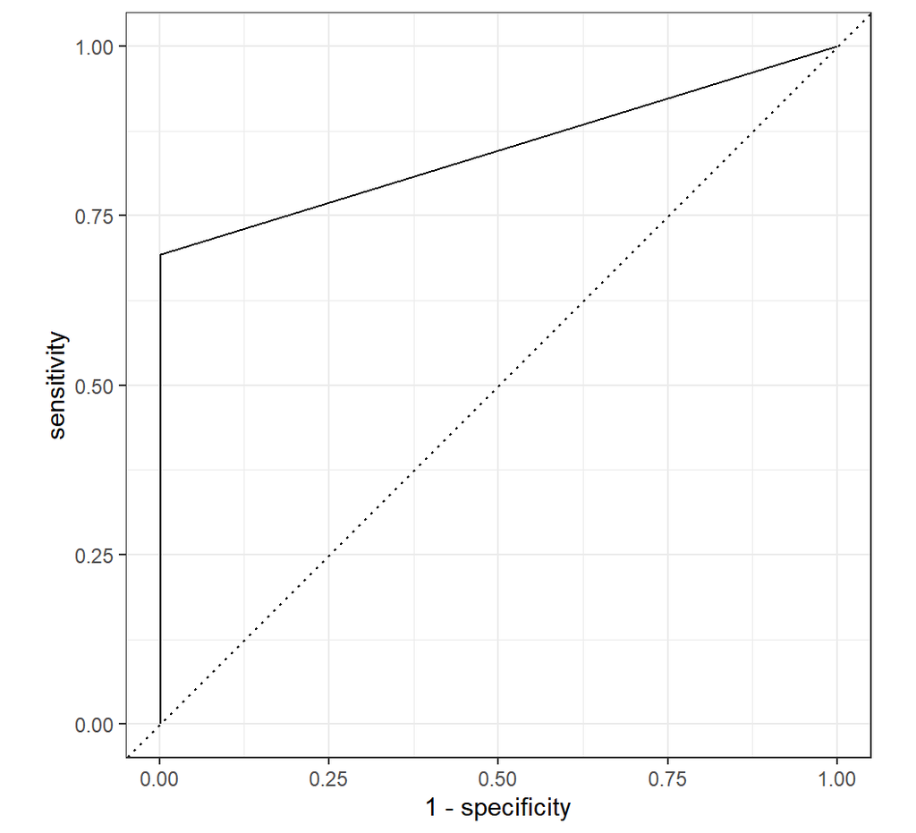

```r
pred = numeric(nrow(holdout_data))

fit = qda(Class~., data = data)
pred = as.numeric(as.character(predict(fit, holdout_data)$class))

eval_data = tibble( y = holdout_data$bluetarp, pred = pred)
# ROC curves
ROC_data = yardstick::roc_curve(eval_data, truth = y, estimate = pred,
                                event_level = "second")
autoplot(ROC_data)
```

```r
qda_AUROC = yardstick::roc_auc_vec(holdout_data$bluetarp, as.numeric(pred), event_level = "second")
perf_thres = map_df(thres, ~get_conf(., y=holdout_data$bluetarp, p_hat = pred)) %>%
  mutate(cost = FN*5 + FP*1)

res <- perf_thres %>%
  slice_min(cost) %>% # choose threshold with minimum costs
  transmute(threshold,Accuracy = (TP + TN)/(TP + FP + FN + TN),
TPR = TP / (TP + FN),
FPR = FP / (FP + TN),
PRE = TP / (TP + FP))
res
```

```
#> # A tibble: 50 x 5
#>    threshold Accuracy   TPR     FPR   PRE
#>        <dbl>    <dbl> <dbl>   <dbl> <dbl>
#>  1    0.05      0.995 0.693 0.00183 0.782
#>  2    0.0531    0.995 0.693 0.00183 0.782
#>  3    0.0561    0.995 0.693 0.00183 0.782
#>  4    0.0592    0.995 0.693 0.00183 0.782
#>  5    0.0622    0.995 0.693 0.00183 0.782
#>  6    0.0653    0.995 0.693 0.00183 0.782
#>  7    0.0684    0.995 0.693 0.00183 0.782
#>  8    0.0714    0.995 0.693 0.00183 0.782
#>  9    0.0745    0.995 0.693 0.00183 0.782
#> 10    0.0776    0.995 0.693 0.00183 0.782
#> # ... with 40 more rows
```

```r
#Met two same min threshold problem
if(length(res) != 1){
  res <- res[1,]
}
qda_threshold = res$threshold
qda_acc = res$Accuracy
qda_tpr = res$TPR
qda_fpr = res$FPR
qda_pre = res$PRE
```

## 4.9 Random Forest

For random forest, I choose mtry as tuning parameter. I set ntree = 200 to save the fitting time. Because we only have 3 variables, I will just use mtry = [1,3].

```r
#-- Settings
#Tuning mtry
#We pre-define ntree to 200.
ntree_max = 200             # maximum number of trees in forest
mtry_seq = seq(1, 3, by=1)  # grid of tuning parameters

perf = tibble()
for(k in 1:10) {
  #-- Set training/test data for fold k
  test = which(fold == k) # indices of holdout/validation data
  train = which(fold != k) # indices of fitting/training data
  n.val = length(test) # number of observations in validation

  for(i in 1:length(mtry_seq)) {
    set.seed(1)
    rf = randomForest(Class~., data=data[train,],
                      mtry=mtry_seq[i], ntree=ntree_max)

    #: estimate probability in hold out set
    p_hat = predict(rf, data[test,], type = "prob")
    #: evaluate performance
    log_loss = yardstick::mn_log_loss_vec(data$Class[test], as.numeric(p_hat[,2]), event_level = "second")
    AUROC = yardstick::roc_auc_vec(data$Class[test], as.numeric(p_hat[,2]), event_level = "second")

    out = tibble(log_loss, AUROC) %>%
      mutate(fold = k, tuning = i, n.val, mtry = mtry_seq[i],
           ntree = ntree_max,
           errorrate = rf$err.rate[ntree_max])

    perf = bind_rows(perf, out)
  }
}
```

### 4.9.1 Tuning Parameters

Cross-validation performance So, mtry = 1 has the least log_loss and largest avg_AUROC.

```r
perf
```

```
#> # A tibble: 30 x 8
#>    log_loss AUROC  fold tuning n.val  mtry ntree errorrate
#>       <dbl> <dbl> <int>  <int> <int> <dbl> <dbl>     <dbl>
#>  1  0.00917 1.00      1      1  6325     1   200   0.00293
#>  2  0.0134  0.997     1      2  6325     2   200   0.00299
#>  3  0.0133  0.997     1      3  6325     3   200   0.00309
#>  4  0.00843 1.00      2      1  6324     1   200   0.00307
#>  5  0.0173  0.995     2      2  6324     2   200   0.00306
#>  6  0.0174  0.995     2      3  6324     3   200   0.00314
#>  7  0.00724 1.00      3      1  6324     1   200   0.00311
#>  8  0.0158  0.995     3      2  6324     2   200   0.00309
#>  9  0.0158  0.995     3      3  6324     3   200   0.00322
#> 10  0.00906 1.00      4      1  6324     1   200   0.00292
#> # ... with 20 more rows
```

```r
(avg_perf = perf %>%
group_by(tuning) %>%
summarize(
avg_log_loss = mean(log_loss),
avg_AUROC = mean(AUROC),
sd_log_loss = sd(log_loss),
sd_AUROC = sd(AUROC)
) %>%
arrange(avg_log_loss, -avg_AUROC))
```

```
#> # A tibble: 3 x 5
#>   tuning avg_log_loss avg_AUROC sd_log_loss sd_AUROC
#>    <int>        <dbl>     <dbl>       <dbl>    <dbl>
#> 1      1      0.00852     1.00      0.00105 0.000129
#> 2      2      0.0203      0.994     0.00592 0.00322
#> 3      3      0.0212      0.994     0.00820 0.00386
```

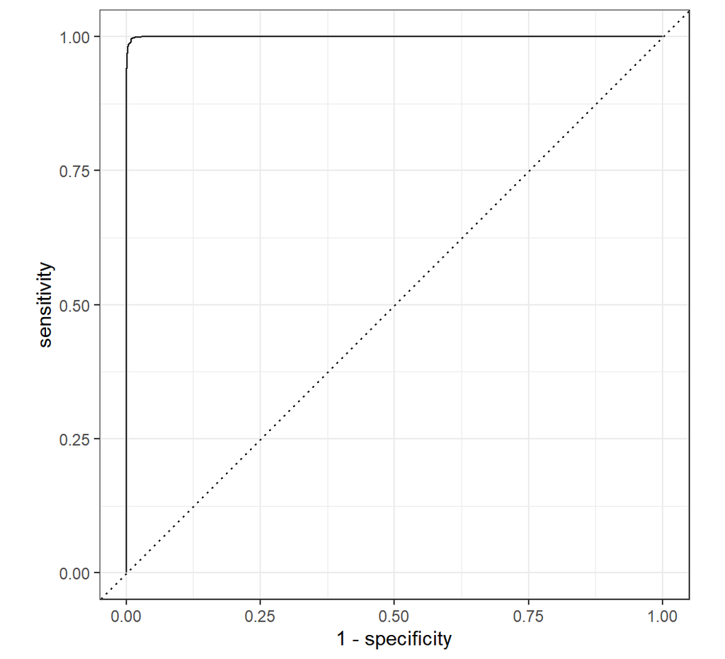

```r
pred = numeric(nrow(data))
for(v in unique(fold)) {
  # set fit/eval split
  ind_fit = which(fold != v)
  ind_eval = which(fold == v)
  fit = randomForest(Class~., data[ind_fit,], mtry=1, ntree=ntree_max)
  # estimate probability in hold out set
  pred[ind_eval] = predict(fit, data[ind_eval,], type = "prob")[,2]
}
eval_data = tibble(
  y = data$Class,
  pred = pred,
  yhat = ifelse(pred > .50, 1, 0) # hard classification
)
# ROC curves
ROC_data = yardstick::roc_curve(eval_data,
  truth = y,
  estimate = pred,
  event_level = "second")
autoplot(ROC_data)
```

```r
rf_cv_AUROC = yardstick::roc_auc_vec(data$Class, as.numeric(pred), event_level = "second")


#parameter importance shows the importance of predictors
fit$importance
```

```
#>       MeanDecreaseGini
#> Red           930.8097
#> Green         616.3665
#> Blue         1798.3480
```

We can see ‘Blue’ variable has the greatest importance. Professor also mentioned this in class that we can only see whether Blue is the greatest or not.

Threshold selection

```r
perf_thres = map_df(thres, ~get_conf(., y=data$Class, p_hat = pred)) %>% mutate(cost = FN*5 + FP*1)

res <- perf_thres %>%
slice_min(cost) %>% # choose threshold with minimum costs
transmute(threshold,
Accuracy = (TP + TN)/(TP + FP + FN + TN),
TPR = TP / (TP + FN),
FPR = FP / (FP + TN),
PRE = TP / (TP + FP))
res
```

```
#> # A tibble: 2 x 5
#>   threshold Accuracy   TPR     FPR   PRE
#>       <dbl>    <dbl> <dbl>   <dbl> <dbl>
#> 1     0.191    0.996 0.981 0.00315 0.911
#> 2     0.194    0.996 0.981 0.00315 0.911
```

```r
#Met two same min threshold problem
if(length(res) != 1){
  res <- res[1,]
}
rf_cv_threshold = res$threshold
rf_cv_acc = res$Accuracy
rf_cv_tpr = res$TPR
rf_cv_fpr = res$FPR
rf_cv_pre = res$PRE
```

Holdout data performance

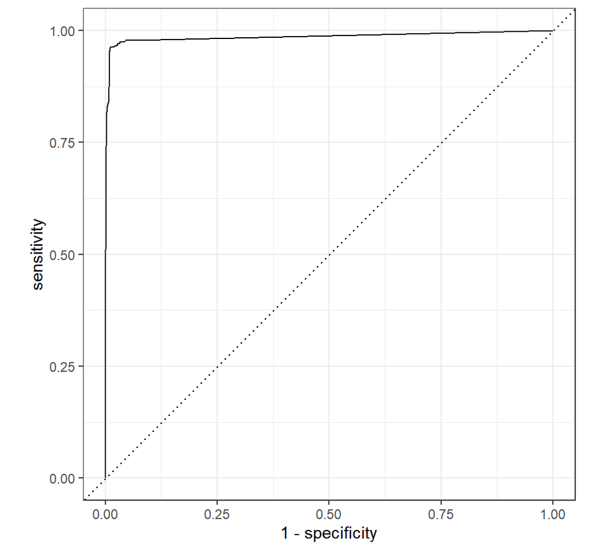

```r
#Evaluate performance of hold-out data by model fit by all training data.
pred = numeric(nrow(holdout_data))

fit = randomForest(Class~., data, mtry=1, ntree=ntree_max)
# estimate probability in hold out set
pred = predict(fit, holdout_data, type = "prob")[,2]

eval_data = tibble(
  y = holdout_data$bluetarp,
  pred = pred,
  yhat = ifelse(pred > .50, 1, 0) # hard classification
)
# ROC curves
ROC_data = yardstick::roc_curve(eval_data,
  truth = y,
  estimate = pred,
  event_level = "second")
autoplot(ROC_data)
```

```r
rf_AUROC = yardstick::roc_auc_vec(holdout_data$bluetarp, as.numeric(pred), event_level = "second")
```

Threshold selection

```r
perf_thres = map_df(thres, ~get_conf(., y=holdout_data$bluetarp, p_hat = pred)) %>% mutate(cost = FN*5 + FP*1)

res <- perf_thres %>%
slice_min(cost) %>% # choose threshold with minimum costs
transmute(threshold,
Accuracy = (TP + TN)/(TP + FP + FN + TN),
TPR = TP / (TP + FN),
FPR = FP / (FP + TN),
PRE = TP / (TP + FP))
res
```

```
#> # A tibble: 2 x 5
#>   threshold Accuracy   TPR    FPR   PRE
#>       <dbl>    <dbl> <dbl>  <dbl> <dbl>
#> 1     0.197    0.988 0.962 0.0113 0.448
#> 2     0.2      0.988 0.962 0.0113 0.448
```

```r
#Met two same min threshold problem
if(length(res) != 1){
  res <- res[1,]
}
rf_threshold = res$threshold
rf_acc = res$Accuracy
rf_tpr = res$TPR
rf_fpr = res$FPR
rf_pre = res$PRE
```

## 4.10 Boosted Trees

For boosted trees, I choose n.tree to tune, this is integer specifying the total number of trees to fit. This is equivalent to the number of iterations and the number of basis functions in the additive expansion.

```r
#
trees =seq(500, 2000, by=500)

perf2 = tibble()

for(k in 1:3) { #Only use three fold for saving calculation time.
  #-- Set training/test data for fold k
  test = which(fold == k) # indices of holdout/validation data
  train = which(fold != k) # indices of fitting/training data
  n.val = length(test) # number of observations in validation

  for(i in trees) {
    set.seed(1)
    gbm1 <- gbm(Class ~ ., data = data[train, ], distribution = "gaussian", cv.folds = 5, n.trees = i, shrinkage = 0.1, interaction.depth = 1)

    best.iter <- gbm.perf(gbm1, method = "cv")
    p_hat = predict(gbm1, data[test,], n.trees = best.iter)
    #: evaluate performance
    log_loss = yardstick::mn_log_loss_vec(data$Class[test], as.numeric(p_hat[]), event_level = "second")
    AUROC = yardstick::roc_auc_vec(data$Class[test], as.numeric(p_hat[]), event_level = "second")

    out = tibble(log_loss, AUROC) %>%
      mutate(fold = k, tuning = i, n.val)
    perf2 = bind_rows(perf2, out)
  }
}
```

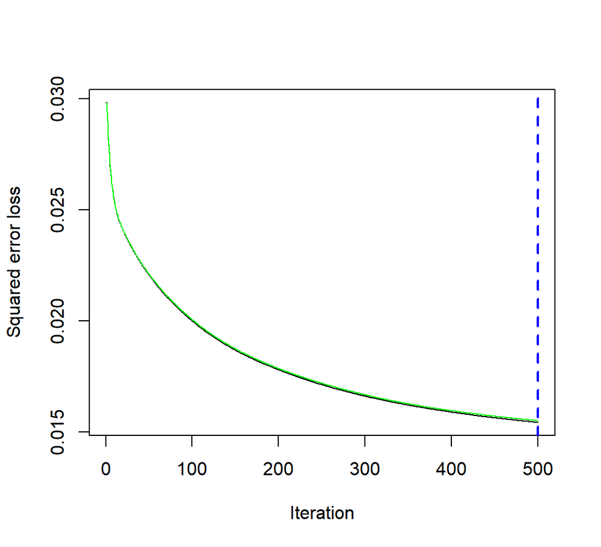

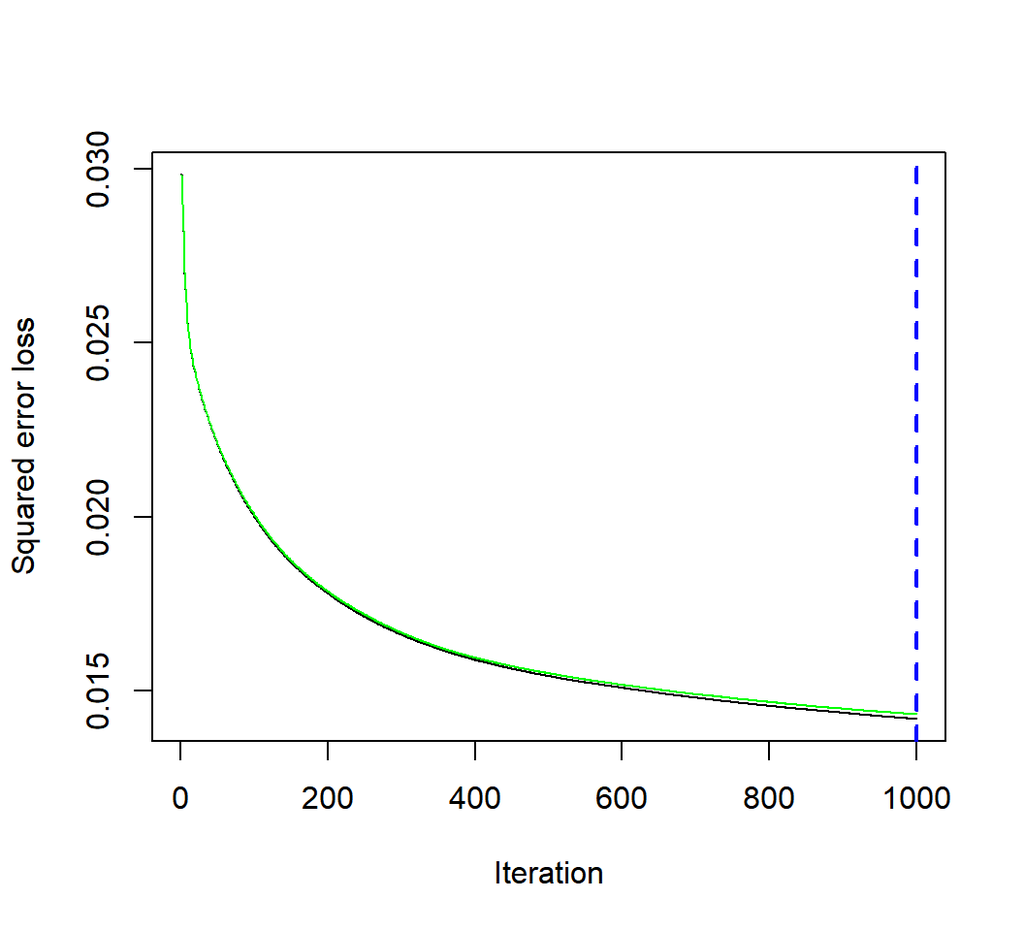

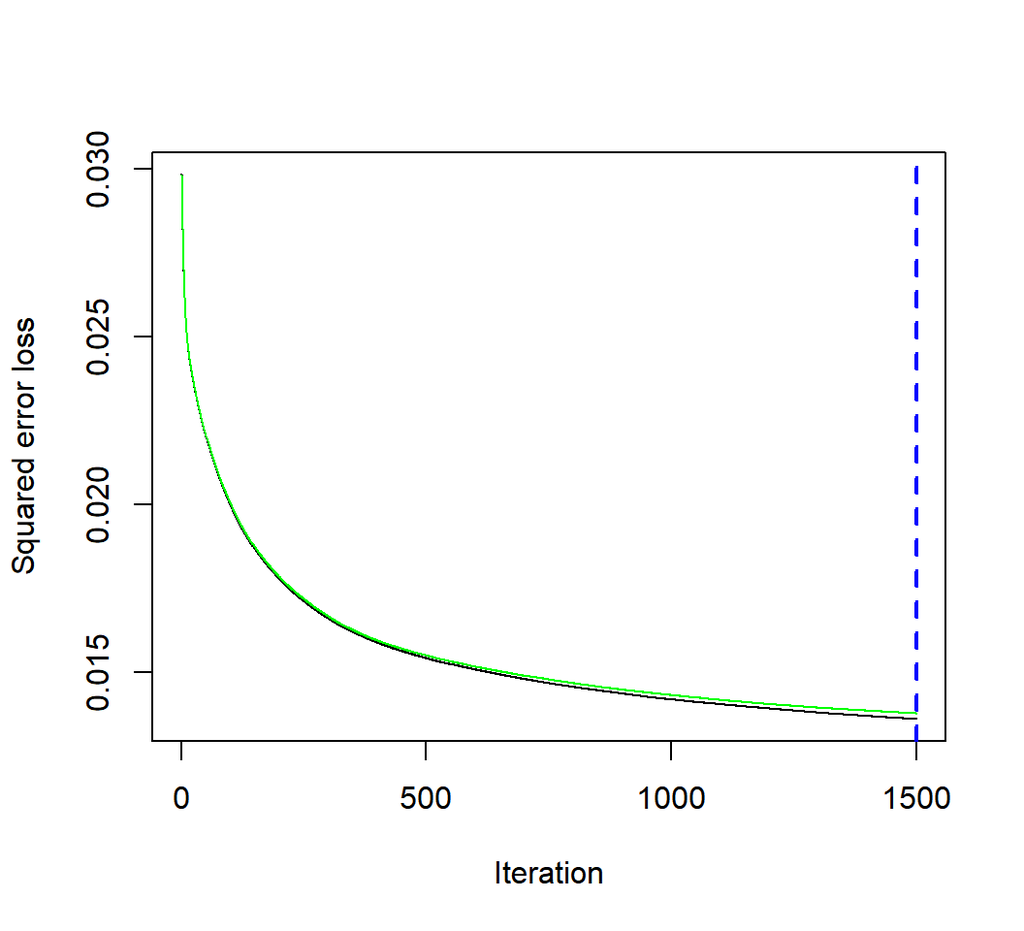

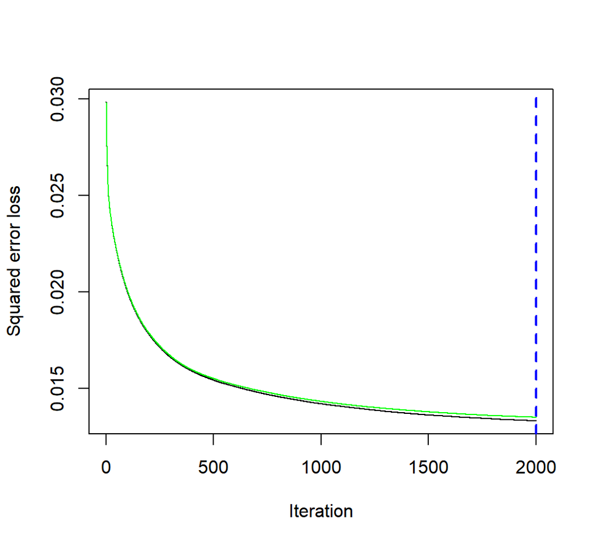

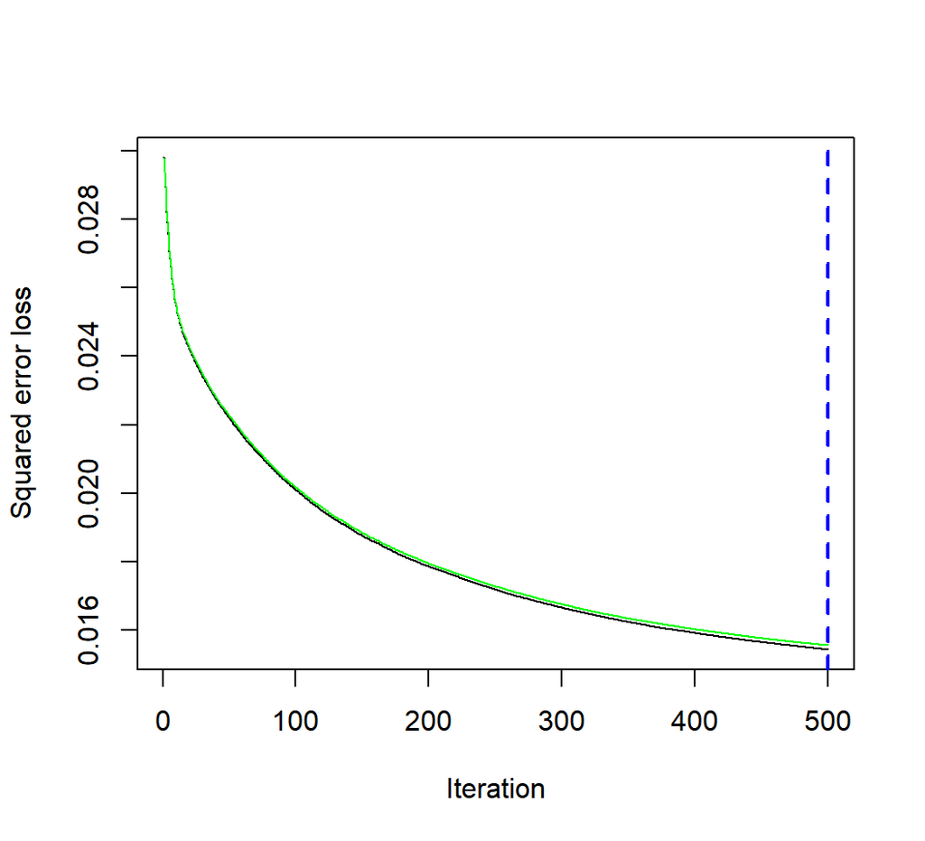

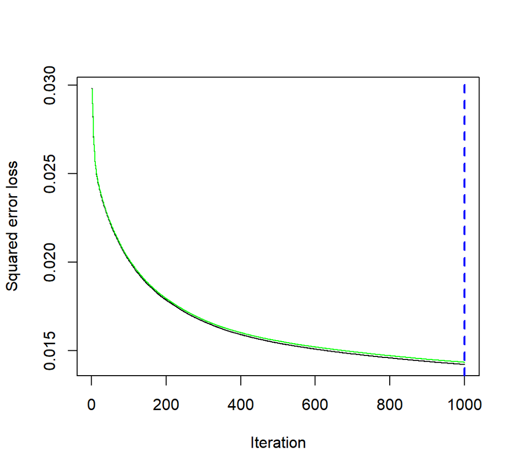

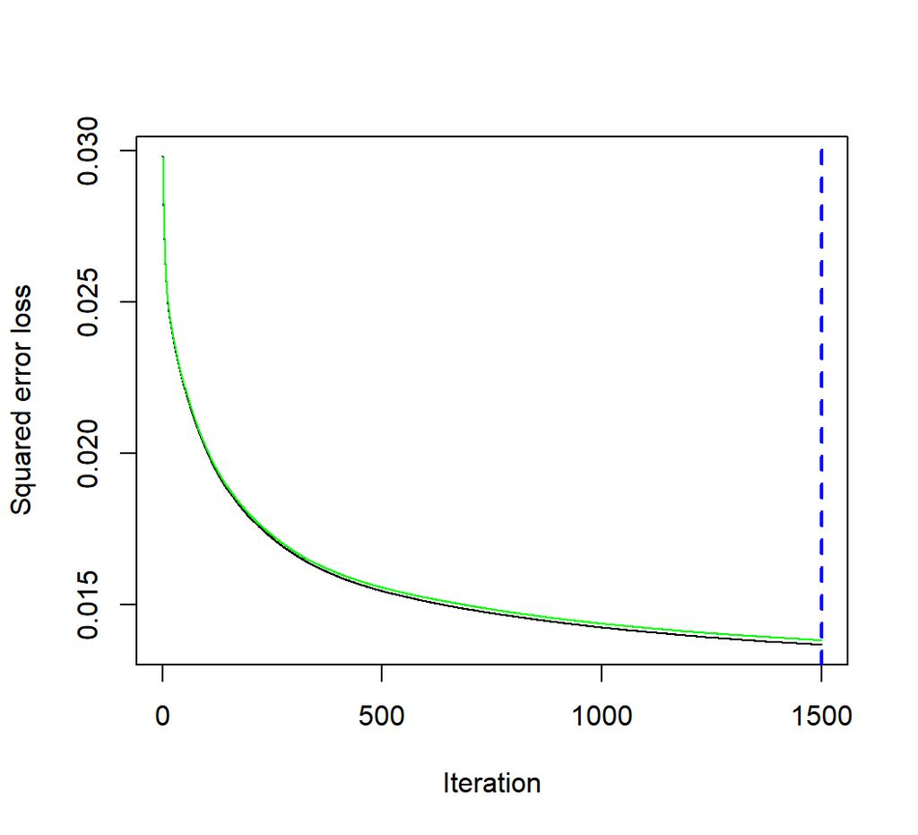

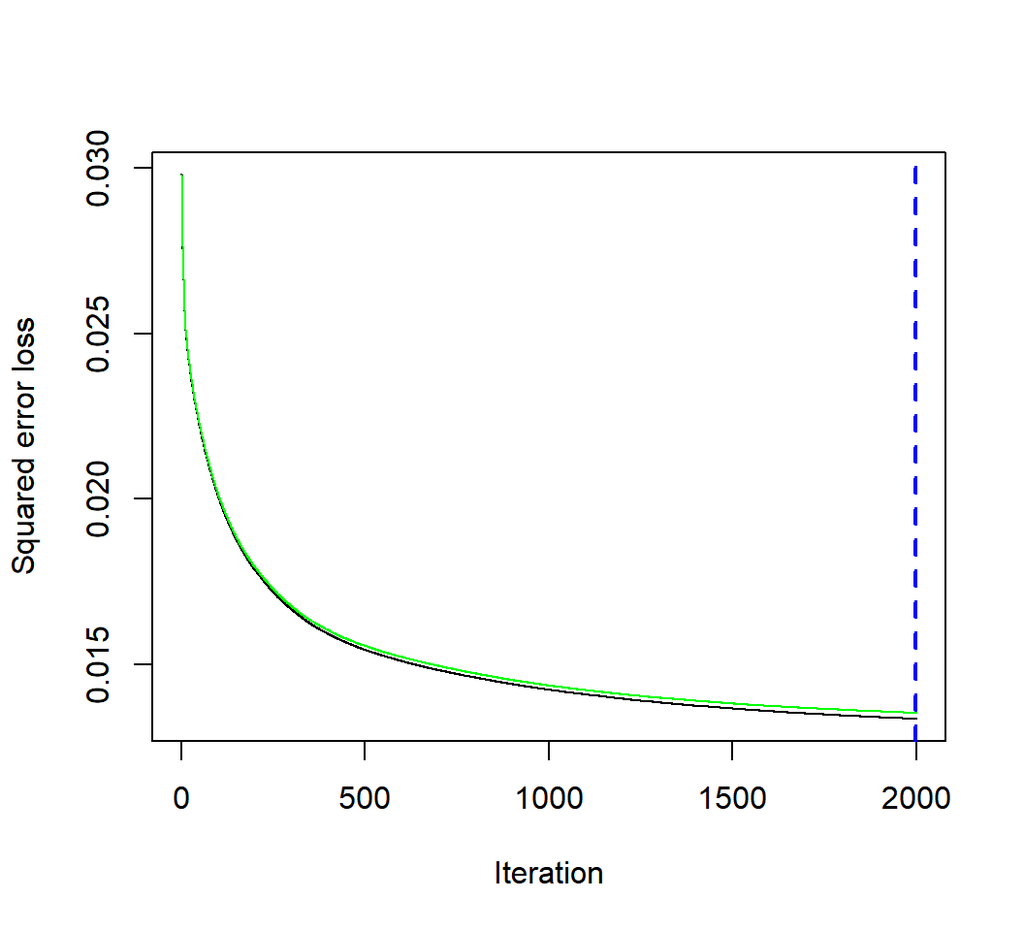

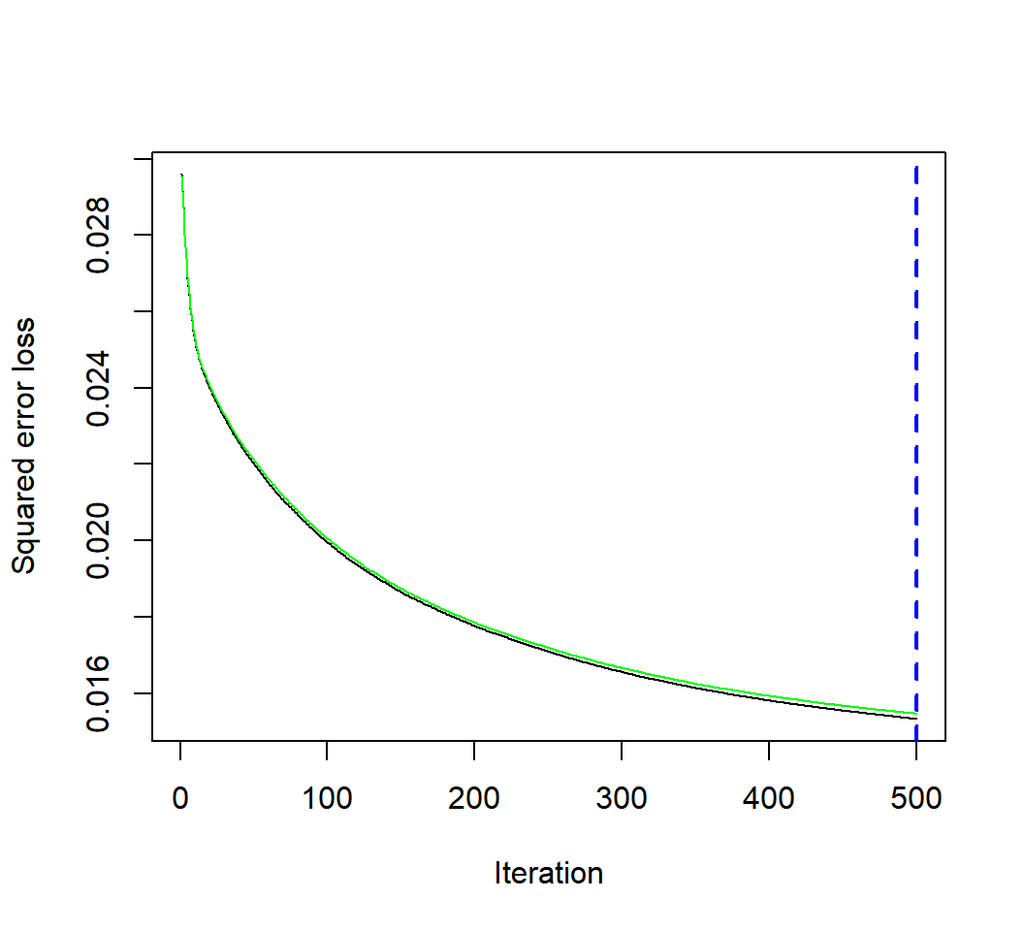

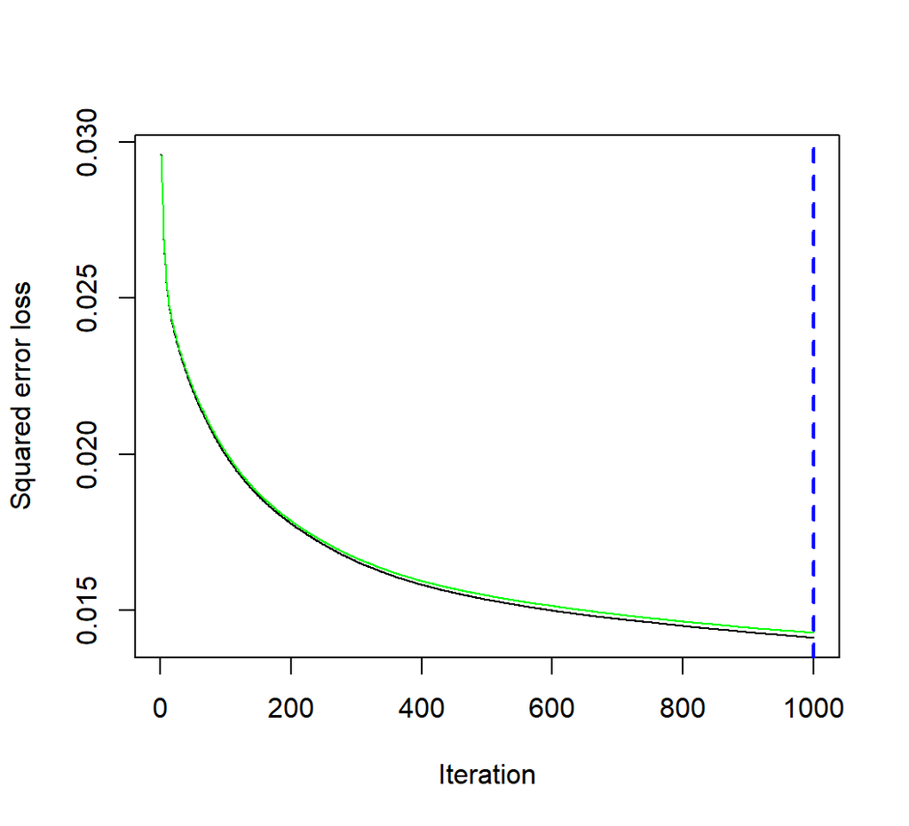

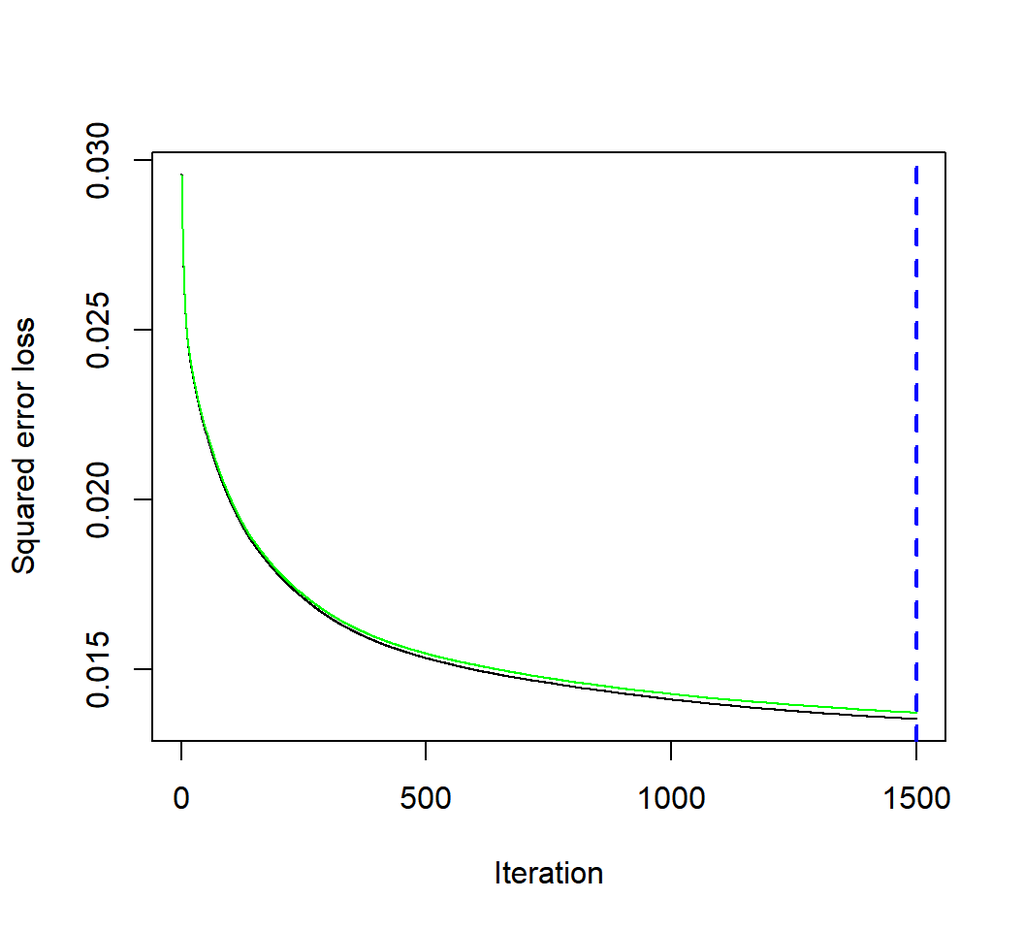

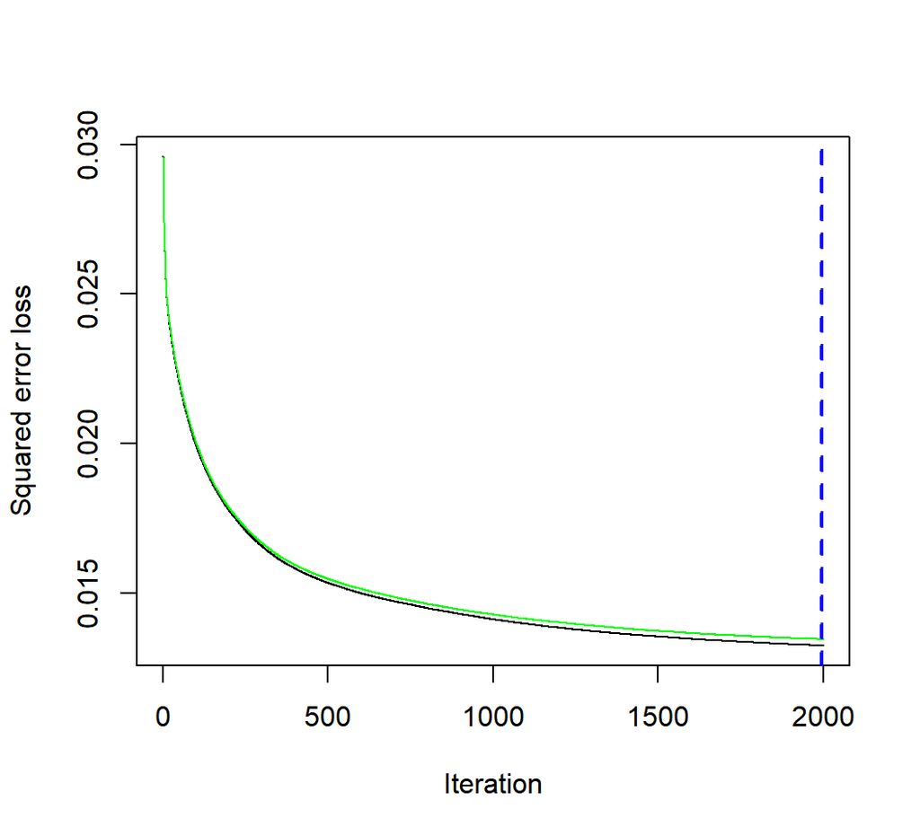

```r
perf2
```

```
#> # A tibble: 12 x 5
#>    log_loss AUROC  fold tuning n.val
#>       <dbl> <dbl> <int>  <dbl> <int>
#>  1     27.5 0.986     1    500  6325
#>  2     26.9 0.993     1   1000  6325
#>  3     27.1 0.995     1   1500  6325
#>  4     27.0 0.996     1   2000  6325
#>  5     27.5 0.984     2    500  6324
#>  6     27.1 0.992     2   1000  6324
#>  7     26.9 0.995     2   1500  6324
#>  8     26.8 0.996     2   2000  6324
#>  9     27.7 0.988     3    500  6324
#> 10     27.3 0.993     3   1000  6324
#> 11     26.9 0.996     3   1500  6324
#> 12     26.8 0.996     3   2000  6324
```

### 4.10.1 Tuning Parameters

Performance of cross-validation in training data. n.trees=2000 is the best hyper-parameter.

```r
(avg_perf = perf2 %>%
group_by(tuning) %>%
summarize(
avg_log_loss = mean(log_loss),
avg_AUROC = mean(AUROC),
sd_log_loss = sd(log_loss),
sd_AUROC = sd(AUROC)
) %>%
arrange(avg_log_loss, -avg_AUROC))
```

```
#> # A tibble: 4 x 5
#>   tuning avg_log_loss avg_AUROC sd_log_loss sd_AUROC
#>    <dbl>        <dbl>     <dbl>       <dbl>    <dbl>
#> 1   2000         26.9     0.996       0.112 0.000132
#> 2   1500         26.9     0.995       0.133 0.000228
#> 3   1000         27.1     0.993       0.196 0.000569
#> 4    500         27.6     0.986       0.122 0.00165
```

```r
#We can see that n.trees = 2000 has the best performance
pred2 = numeric(nrow(data))
for(v in unique(fold)) {
  # set fit/eval split
  ind_fit = which(fold != v)
  ind_eval = which(fold == v)
  fit2 <- gbm(Class ~ ., data = data[ind_fit, ],distribution = "gaussian", cv.folds = 5, n.trees = 2000, shrinkage = 0.1, interaction.depth = 1)
  best.iter <- gbm.perf(fit2, method = "cv")
  # estimate probability in hold out set
  pred2[ind_eval] = predict(fit2, data[ind_eval,], n.trees = best.iter)
}
```

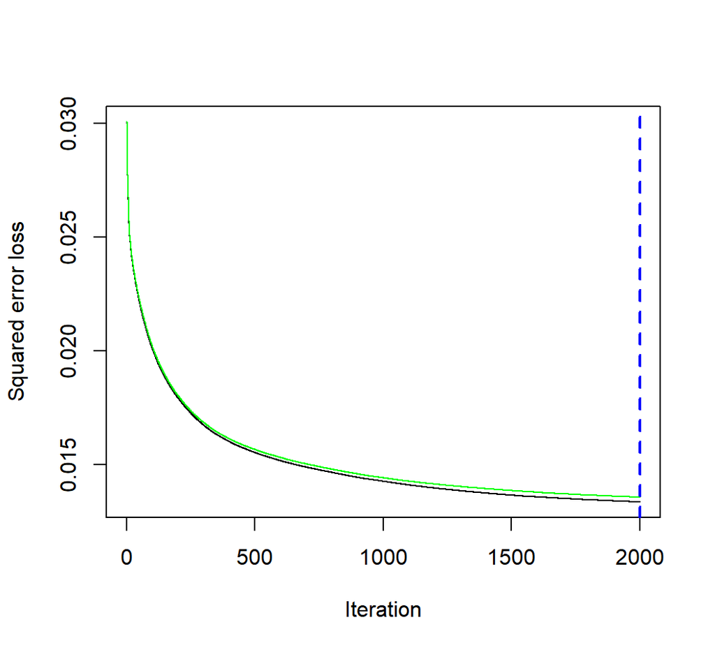

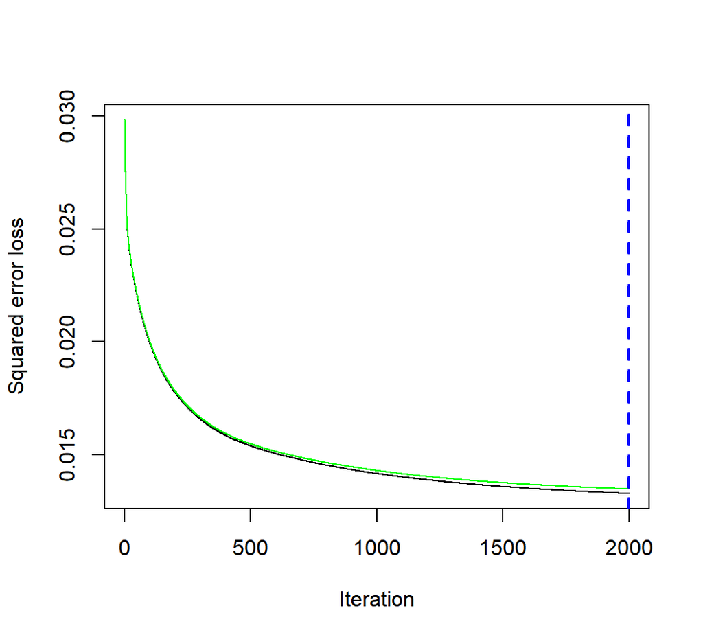

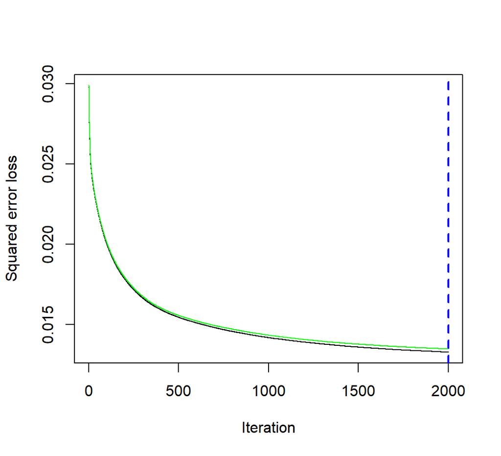

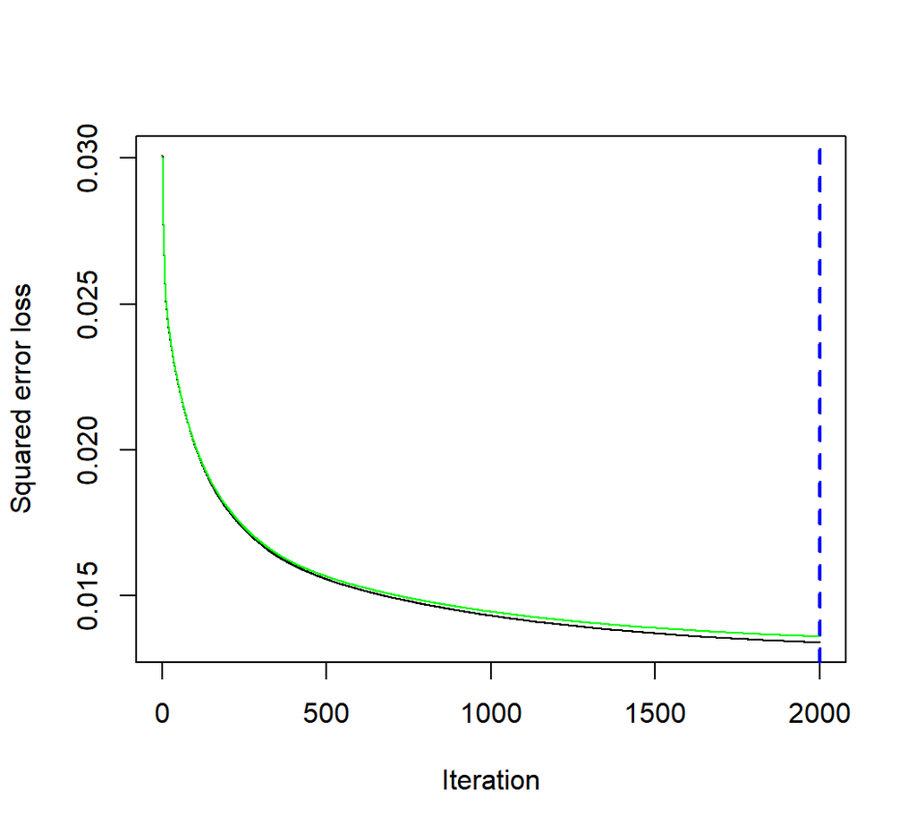

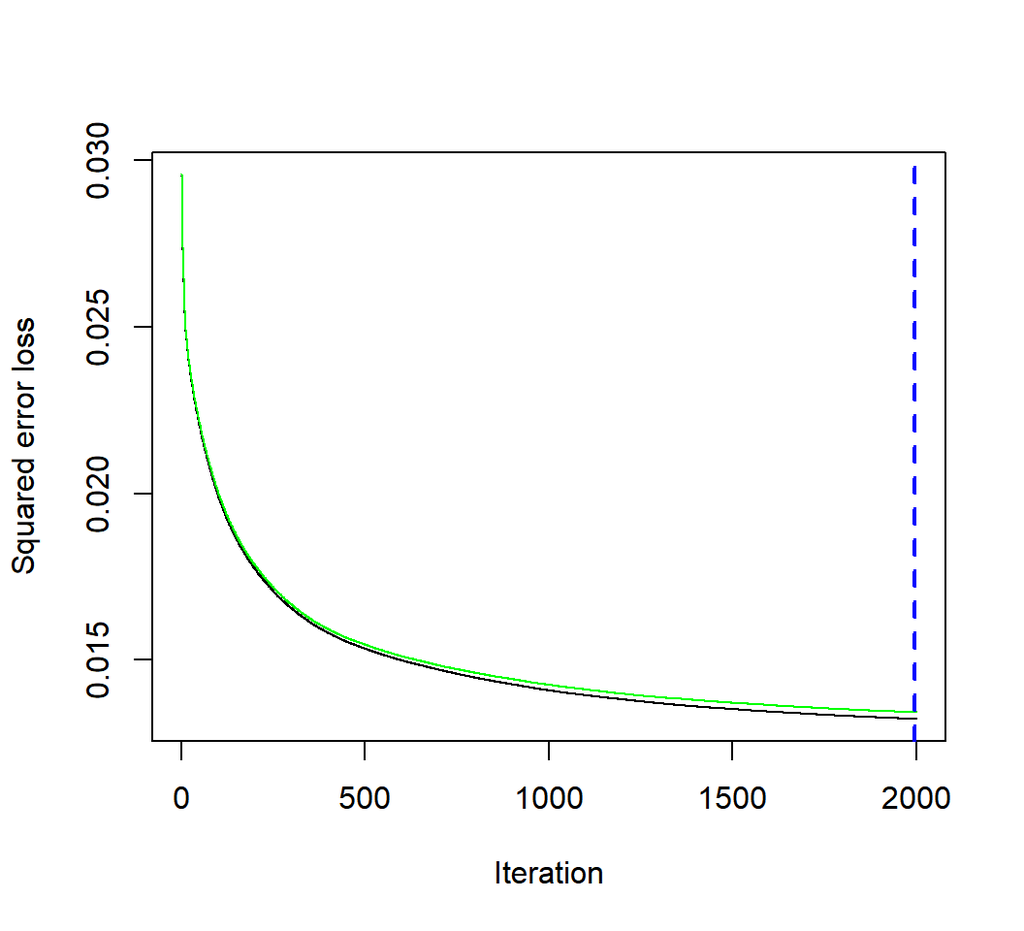

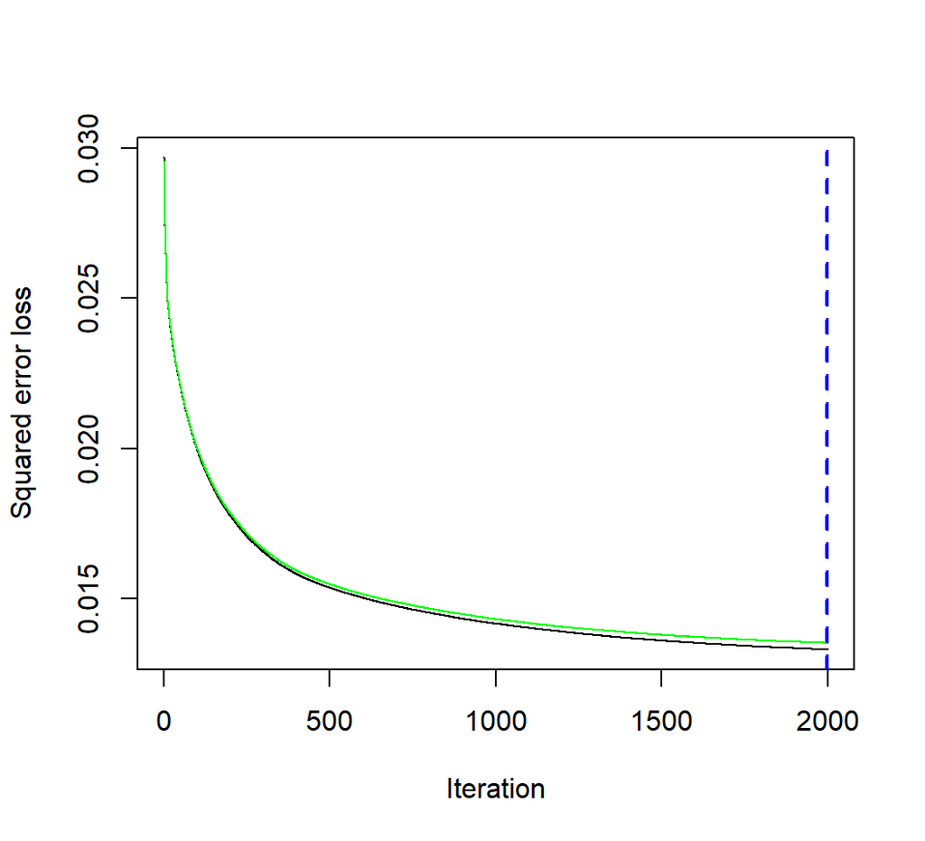

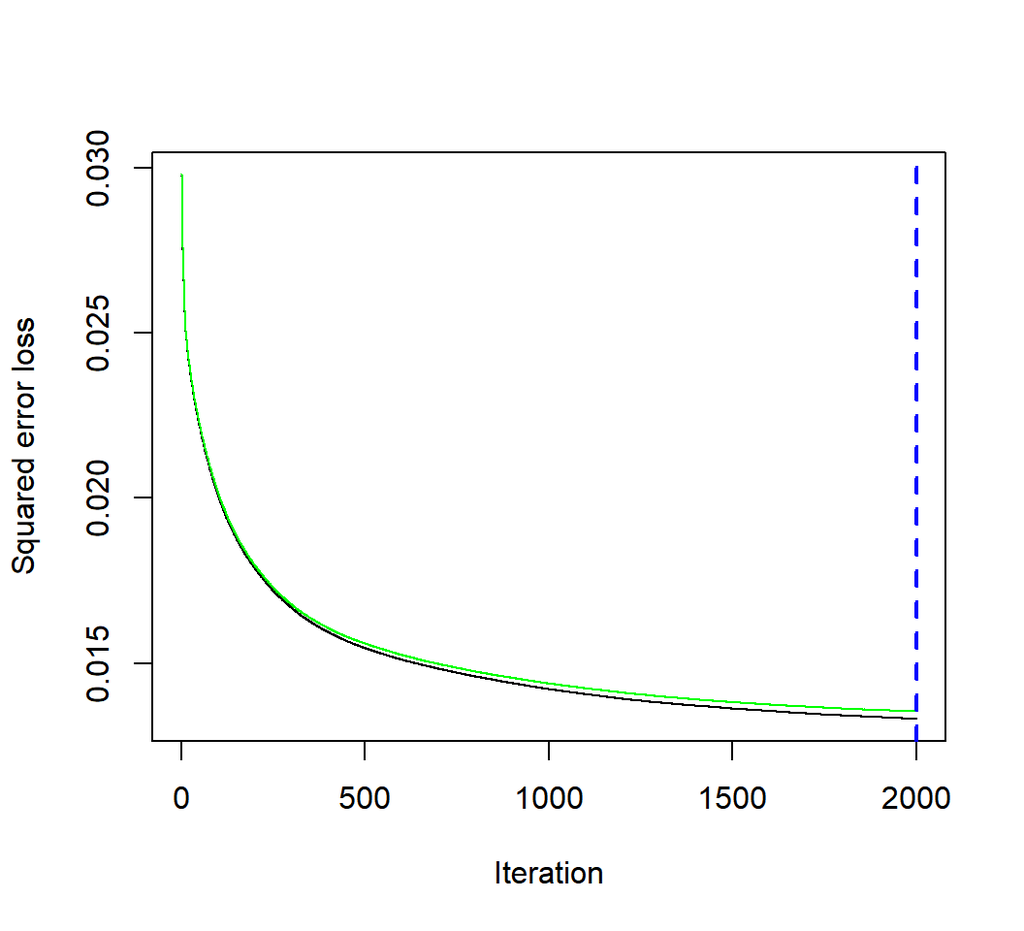

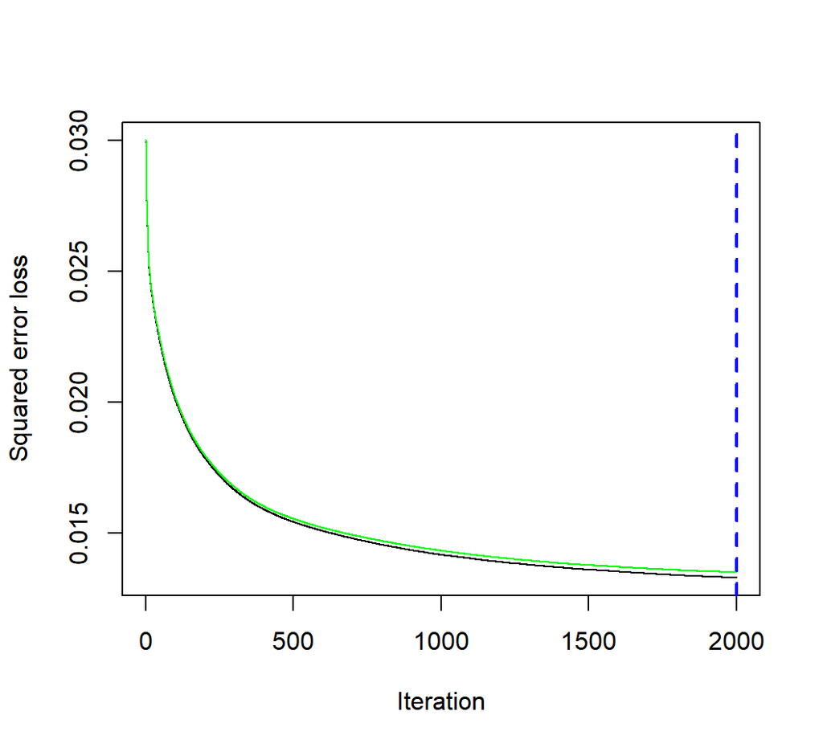

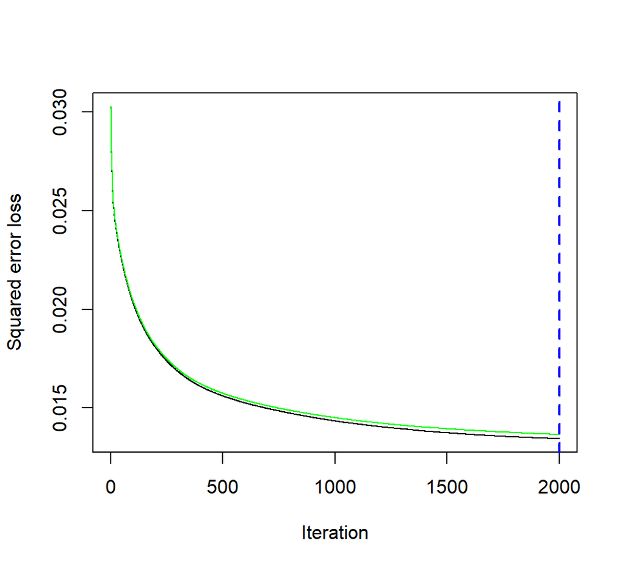

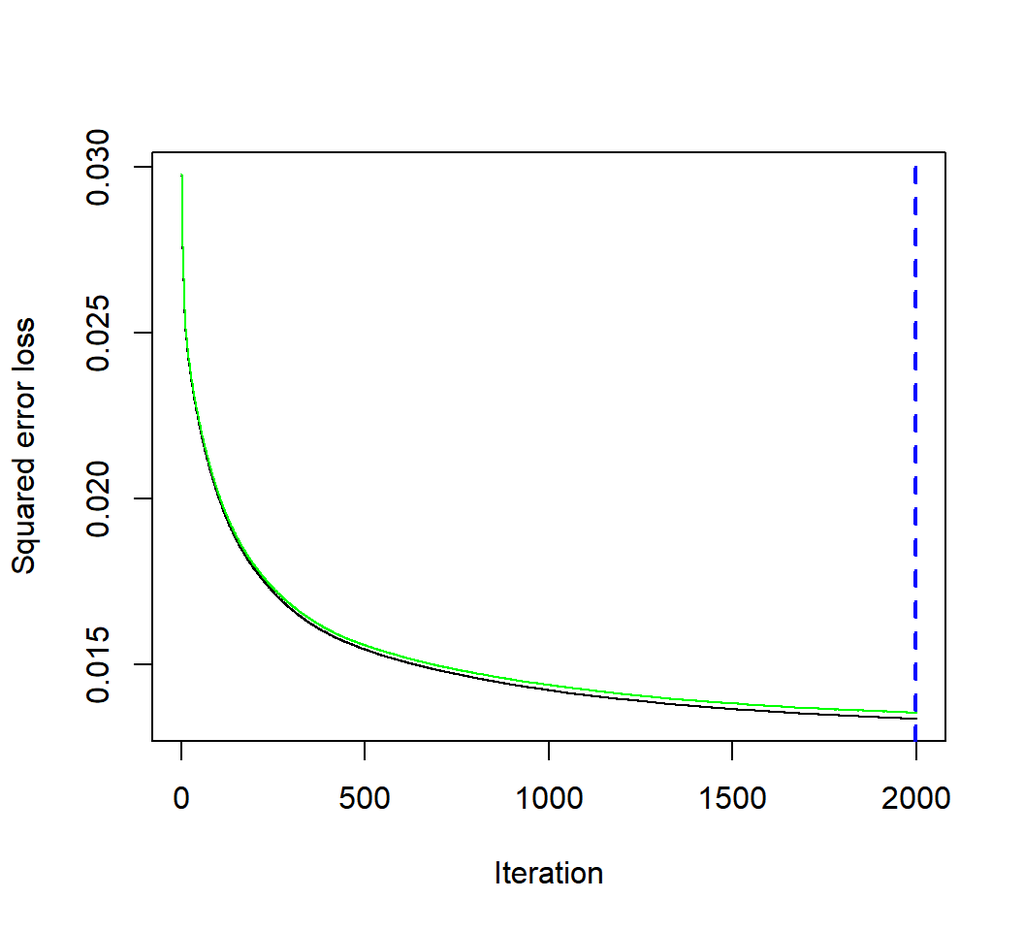

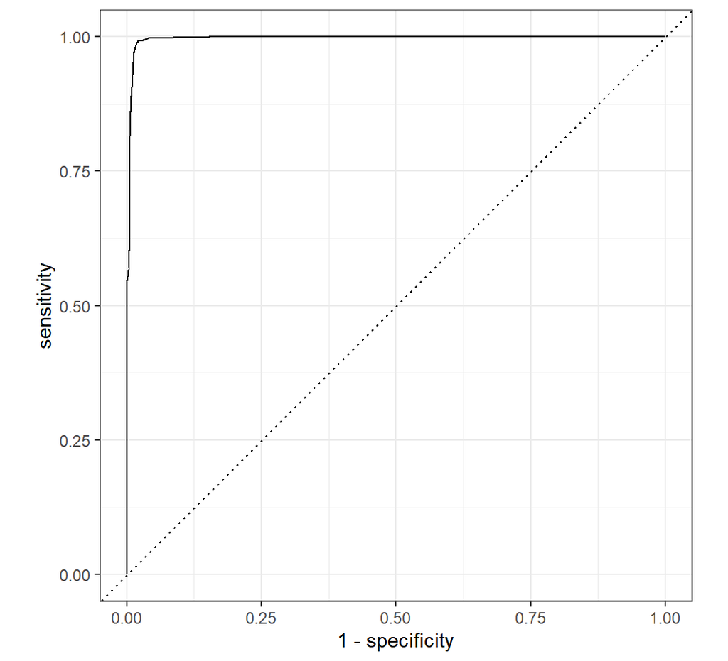

```r
eval_data = tibble(
  y = data$Class,
  pred2 = pred2,
)

# ROC curves
ROC_data = yardstick::roc_curve(eval_data,
  truth = y,
  estimate = pred2,
  event_level = "second")
autoplot(ROC_data)
```

```r
bt_cv_AUROC = yardstick::roc_auc_vec(data$Class, as.numeric(pred2), event_level = "second")
```

```r
#For threshold, the outcome of gbm is in a range of 1 to 1.5. So I pick value in between this range.
thres2 = seq(1.0, 1.50, length=50)
perf_thres2 = map_df(thres2, ~get_conf(., y=data$Class, p_hat = pred2)) %>% mutate(cost = FN*5 + FP*1)

res2 <- perf_thres2 %>%
slice_min(cost) %>% # choose threshold with minimum costs
transmute(threshold,
Accuracy = (TP + TN)/(TP + FP + FN + TN),
TPR = TP / (TP + FN),
FPR = FP / (FP + TN),
PRE = TP / (TP + FP))
res2
```

```
#> # A tibble: 1 x 5
#>   threshold Accuracy   TPR    FPR   PRE
#>       <dbl>    <dbl> <dbl>  <dbl> <dbl>
#> 1      1.26    0.985 0.973 0.0145 0.689
```

```r
bt_cv_threshold = res2$threshold
bt_cv_acc = res2$Accuracy
bt_cv_tpr = res2$TPR
bt_cv_fpr = res2$FPR
bt_cv_pre = res2$PRE
```

Holdout data performance

```r
pred2 = numeric(nrow(holdout_data))

fit2 <- gbm(Class ~ ., data = data ,distribution = "gaussian", cv.folds = 5, n.trees = 2000, shrinkage = 0.1, interaction.depth = 1)
best.iter <- gbm.perf(fit2, method = "cv")
```

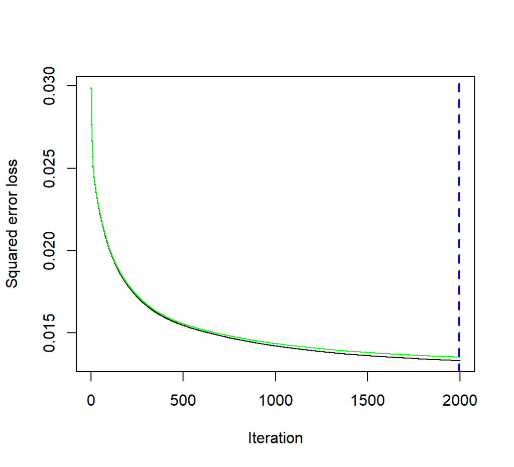

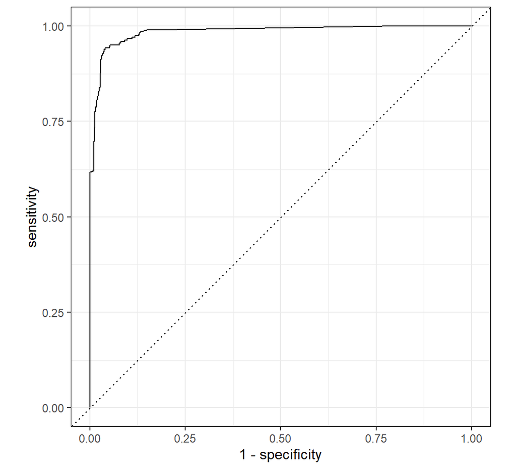

```r
# estimate probability in hold out set
pred2 = predict(fit2, holdout_data, n.trees = best.iter)

eval_data = tibble(
  y = holdout_data$bluetarp,
  pred2 = pred2,
)

# ROC curves
ROC_data = yardstick::roc_curve(eval_data,
  truth = y,
  estimate = pred2,
  event_level = "second")
autoplot(ROC_data)
```

```r
bt_AUROC = yardstick::roc_auc_vec(holdout_data$bluetarp, as.numeric(pred2), event_level = "second")
```

```r
perf_thres2 = map_df(thres2, ~get_conf(., y=holdout_data$bluetarp, p_hat = pred2)) %>% mutate(cost = FN*5 + FP*1)

res2 <- perf_thres2 %>%
slice_min(cost) %>% # choose threshold with minimum costs
transmute(threshold,
Accuracy = (TP + TN)/(TP + FP + FN + TN),
TPR = TP / (TP + FN),
FPR = FP / (FP + TN),
PRE = TP / (TP + FP))
res2
```

```
#> # A tibble: 1 x 5
#>   threshold Accuracy   TPR    FPR   PRE
#>       <dbl>    <dbl> <dbl>  <dbl> <dbl>
#> 1      1.39    0.984 0.777 0.0141 0.343
```

```r
bt_threshold = res2$threshold
bt_acc = res2$Accuracy
bt_tpr = res2$TPR
bt_fpr = res2$FPR
bt_pre = res2$PRE
```

## 4.11 Threshold Selection

Already discussed above in logistic part.

# 5 Results (Hold-Out)

Displayed in end of each model section

## 5.1 Cross-Validation Performance Table

We take average for every result in cross-validation. This table represents the result of best hyper-parameter model by cross-validation in training dataset.

```r
library(knitr)
performance_table = tibble(Model=c("Log Reg", "KNN", "Penalized Log Reg", "SVM", "Naive Bayes", "LDA", "QDA", "Random Forest", "Boosted Tree"), Tuning=c("None", "k=15", "alpha=1, lambda=2.229459e-05","gamma=2, cost=400", "None", "None", "None", "mtry=1, ntree=200", "n.trees=2000"), AUROC= c(lg_cv_AUROC, knn_cv_AUROC, eln_cv_AUROC, svm_cv_AUROC, nb_cv_AUROC, lda_cv_AUROC, qda_cv_AUROC, rf_cv_AUROC, bt_cv_AUROC), Threshold=c(lg_cv_threshold, knn_cv_threshold, eln_cv_threshold, svm_cv_threshold, nb_cv_threshold, lda_cv_threshold, qda_cv_threshold, rf_cv_threshold, bt_cv_threshold), Accuracy=c(lg_cv_acc, knn_cv_acc, eln_cv_acc, svm_cv_acc, nb_cv_acc, lda_cv_acc, qda_cv_acc, rf_cv_acc, bt_cv_acc ), TPR=c(lg_cv_tpr,knn_cv_tpr,eln_cv_tpr,svm_cv_tpr, nb_cv_tpr, lda_cv_tpr, qda_cv_tpr, rf_cv_tpr, bt_cv_tpr), FPR=c(lg_cv_fpr, knn_cv_fpr,eln_cv_fpr,svm_cv_fpr, nb_cv_fpr, lda_cv_fpr, qda_cv_fpr, rf_cv_fpr, bt_cv_fpr), Precision=c(lg_cv_pre, knn_cv_pre, eln_cv_pre, svm_cv_pre, nb_cv_pre, lda_cv_pre, qda_cv_pre, rf_cv_pre, bt_cv_pre))
knitr::kable(performance_table, "pipe")
```

| Model | Tuning | AUROC | Threshold | Accuracy | TPR | FPR | Precision |
| --- | --- | --- | --- | --- | --- | --- | --- |
| Log Reg | None | 0.9984860 | 0.0989796 | 0.9907971 | 0.9653808 | 0.0083634 | 0.7922078 |
| KNN | k=15 | 0.9769140 | 0.0500000 | 0.9965054 | 0.9559842 | 0.0021562 | 0.9360775 |
| Penalized Log Reg | alpha=1, lambda=2.229459e-05 | 0.9995754 | 0.0897959 | 0.9957306 | 0.9841741 | 0.0038877 | 0.8931777 |
| SVM | gamma=2, cost=400 | 0.9997033 | 0.1448980 | 0.9969798 | 0.9787339 | 0.0024176 | 0.9304184 |
| Naive Bayes | None | 0.9090907 | 0.1663265 | 0.9875714 | 0.6854599 | 0.0024502 | 0.9023438 |
| LDA | None | 0.8952987 | 0.0500000 | 0.9838554 | 0.8006924 | 0.0100949 | 0.7237371 |
| QDA | None | 0.9197343 | 0.0500000 | 0.9945921 | 0.8397626 | 0.0002940 | 0.9895105 |
| Random Forest | mtry=1, ntree=200 | 0.9996614 | 0.1908163 | 0.9963315 | 0.9807122 | 0.0031526 | 0.9113051 |
| Boosted Tree | n.trees=2000 | 0.9963178 | 1.2551020 | 0.9850730 | 0.9732938 | 0.0145380 | 0.6885934 |

## 5.2 Hold-out Performance Table

This table represents the result of best model fitted by training dataset, and evaluate with hold-out dataset.

```r
library(knitr)
performance_table = tibble(Model=c("Log Reg", "KNN", "Penalized Log Reg", "SVM",  "Naive Bayes", "LDA", "QDA", "Random Forest", "Boosted Tree"), Tuning=c("None", "k=15", "alpha=1, lambda=2.229459e-05","gamma=2, cost=400", "None", "None", "None", "mtry=1, ntree=200", "n.trees=2000"), AUROC=c(lg_AUROC, knn_AUROC, eln_AUROC, svm_AUROC, nb_AUROC, lda_AUROC, qda_AUROC, rf_AUROC, bt_AUROC), Threshold=c(lg_threshold, knn_threshold, eln_threshold, svm_threshold, nb_threshold, lda_threshold, qda_threshold, rf_threshold, bt_threshold), Accuracy=c(lg_acc, knn_acc, eln_acc, svm_acc, nb_acc,lda_acc, qda_acc,rf_acc, bt_acc), TPR=c(lg_tpr,knn_tpr,eln_tpr,svm_tpr,nb_tpr, lda_tpr, qda_tpr, rf_tpr, bt_tpr), FPR=c(lg_fpr, knn_fpr,eln_fpr,svm_fpr, nb_fpr, lda_fpr, qda_fpr, rf_fpr, bt_fpr), Precision=c(lg_pre, knn_pre, eln_pre, svm_pre, nb_pre, lda_pre, qda_pre, rf_pre, bt_pre))
knitr::kable(performance_table, "pipe")
```

| Model | Tuning | AUROC | Threshold | Accuracy | TPR | FPR | Precision |
| --- | --- | --- | --- | --- | --- | --- | --- |
| Log Reg | None | 0.9993877 | 0.2000000 | 0.9524555 | 0.9984149 | 0.0479817 | 0.1652254 |
| KNN | k=15 | 0.9993877 | 0.2000000 | 0.9524555 | 0.9984149 | 0.0479817 | 0.1652254 |
| Penalized Log Reg | alpha=1, lambda=2.229459e-05 | 0.9975448 | 0.0500000 | 0.9913737 | 0.0844869 | 0.0000000 | 1.0000000 |
| SVM | gamma=2, cost=400 | 0.9365903 | 0.2000000 | 0.9862802 | 0.5425341 | 0.0094989 | 0.3520296 |
| Naive Bayes | None | 0.7977577 | 0.2000000 | 0.9903501 | 0.2324316 | 0.0024406 | 0.4753106 |
| LDA | None | 0.9142519 | 0.0500000 | 0.9814973 | 0.8457149 | 0.0172112 | 0.3185210 |
| QDA | None | 0.8456164 | 0.0500000 | 0.9952903 | 0.6930677 | 0.0018350 | 0.7822638 |
| Random Forest | mtry=1, ntree=200 | 0.9863623 | 0.1969388 | 0.9884737 | 0.9624326 | 0.0112786 | 0.4480274 |
| Boosted Tree | n.trees=2000 | 0.9845270 | 1.3877551 | 0.9838915 | 0.7772377 | 0.0141429 | 0.3432905 |

# 6 Final Conclusions

### 6.0.2 Conclusion #2

Why random forest is the best when we have other models have better performance metrics compared to random forest? I want to dissucss in two points.

First, I will our model have the best performance in real case. And in our disaster situation, like I mentioned in Threshold Selection part, we focus more on false negative because we do not want to miss any possible civilians. So, I wish to select the best model by tpr rate and accuracy rate.

Second, I think random forest still have potential to improve. The tuning parameter I chose is mtry. And I set ntree=200 which could be larger than that.

### 6.0.3 Conclusion #3

My recommendation of model to use for detection blue tarps will random forest model. Like the point I mentioned above, we need to decrease of FN so we need a model has high TPR rate (recall rate). At the same time, the other models have disadvantages like logistic regression and knn are overfitting, SVM and boosted tree are complicated and time consuming to train a model. So, random forest will be a good choice for detecting image of bluetarp.

### 6.0.4 Conclusion #4

From above tables, we can see most of models have a low precision rate in holdout data performance. I think this is because the unbalance in training and hold-out data. We have only 1-3% of data is blue tarp. Therefore, one false positive occur, it has big effect on the whole precision rate. Additive, in our threshold selection, we made false negative has more cost than false positive. It leads our model sacrifice more percision for a high recall(tpr). And for fpr, because it is calculated by fp/(fp+tn) and our tn(right non-bluetarp prediction) is large. It has a low number in both cv and holdout data performance.

### 6.0.6 Conclusion #6

Personally, I think this project is very close to a real-world situation. We experienced an overall, integrated, and detailed project that also suits for real-scenario case. We have a deep understanding of what should we do in each step such as pre-processing data, EDA, tuning parameter, cross-validation and tons of details inside it. This final and integrated project contains most of model we learned in this semester. We fitted all these model in same data and compare their performances to pick the best one. I think this is how the real-world case works as well. After finished this project, I am more confident if I meet another data mining problem in future because of experience I learned from it.